# **Supplement Section B: Inferential statistics**

## **• B1:** Comprehensive models with exploratory variables and variable exclusion process

## **• B2:** Unsplit models (without stimulus type separation)

## **• B3:** Complete models including control condition

## **• B4:** Factorial 2x2 models

## **• B5:** Normality assessments and Model assumptions

## **• B6:** Power Analysis

## **• B7:** Expected vs. Observed ratings of item photographs

## **• B8:** Walking Proficiency in the Video Stimuli

#### **In the .Pdf output file you may find only the outputs generated by the analysis code, in order to keep the supplementary files as concise as possible. However the full code is available on https://github.com/Rezvani-S/Costly-Beauty-ShoeStudy.git**

## 1. Required Packages

## 2. Data Import and Preparation

## **PART I: Supplement B1: Comprehensive models with exploratory variables and variable exclusion process**

## 3. Data Cleaning and Preparation

## 4. Comprehensive Attractiveness Model

A comprehensive linear mixed-effects model for attractiveness was constructed, including all potential variables:

```
## Linear mixed model fit by REML. t-tests use Satterthwaite's method [
## lmerModLmerTest]
## Formula: Rating ~ Condition + sex + monthlyincome + merged_score_zscore +
##     Stimuli_Type + (1 | block/Model) + (1 | code)
##    Data: body_df_attract
##
## REML criterion at convergence: 47192.8
##
## Scaled residuals:
##     Min      1Q  Median      3Q     Max
## -4.9177 -0.6141 -0.0090  0.6115  4.3914
##
## Random effects:
##  Groups      Name        Variance  Std.Dev.
##  code        (Intercept) 1.718e+00 1.3108014
##  Model:block (Intercept) 6.051e-01 0.7778898
##  block       (Intercept) 3.105e-08 0.0001762
##  Residual                1.784e+00 1.3355910
## Number of obs: 13435, groups:  code, 275; Model:block, 54; block, 11
##
## Fixed effects:
##                         Estimate Std. Error         df t value Pr(>|t|)
## (Intercept)            5.679e+00  2.242e-01  3.054e+02  25.325  < 2e-16 ***
## ConditionEconomy Flat -1.474e-01  3.643e-02  1.311e+04  -4.045 5.26e-05 ***
## ConditionEconomy Heel  2.179e-02  3.643e-02  1.311e+04   0.598 0.549834
## ConditionLuxury Flat  -1.257e-01  3.643e-02  1.311e+04  -3.450 0.000562 ***
## ConditionLuxury Heel  -1.552e-01  3.645e-02  1.311e+04  -4.259 2.06e-05 ***
## sexMale               -1.580e-01  1.842e-01  2.659e+02  -0.858 0.391641
## monthlyincome.L        4.441e-01  4.196e-01  2.706e+02   1.059 0.290753
## monthlyincome.Q        1.810e-01  3.587e-01  2.692e+02   0.505 0.614213
## monthlyincome.C        4.240e-01  2.874e-01  2.709e+02   1.475 0.141284
## merged_score_zscore   -5.405e-03  1.011e-01  2.698e+02  -0.053 0.957388
## Stimuli_TypeVideo     -5.135e-01  2.305e-02  1.311e+04 -22.281  < 2e-16 ***
## ---
## Signif. codes:  0 '***' 0.001 '**' 0.01 '*' 0.05 '.' 0.1 ' ' 1
##
## Correlation of Fixed Effects:
##             (Intr) CndtEF CndtEH CndtLF CndtLH sexMal mnth.L mnth.Q mnth.C
## CndtnEcnmyF -0.081
## CndtnEcnmyH -0.081  0.500
## CndtnLxryFl -0.081  0.500  0.500
## CndtnLxryHl -0.081  0.500  0.500  0.500
## sexMale     -0.362  0.000  0.000  0.000  0.000
## mnthlyncm.L  0.688  0.000  0.000  0.000  0.000 -0.040
## mnthlyncm.Q  0.339  0.000  0.000  0.000  0.000  0.087  0.747
## mnthlyncm.C  0.133  0.000  0.000  0.000  0.000  0.050  0.297  0.602
## mrgd_scr_zs -0.107  0.000  0.000  0.000  0.000  0.375  0.015  0.012 -0.055
## Stiml_TypVd -0.051  0.000  0.000  0.000  0.000  0.000  0.000  0.000  0.000
##             mrgd__
## CndtnEcnmyF
## CndtnEcnmyH
## CndtnLxryFl
## CndtnLxryHl
## sexMale
## mnthlyncm.L
## mnthlyncm.Q
## mnthlyncm.C
## mrgd_scr_zs
## Stiml_TypVd  0.000
```

### ANOVA for Fixed Effects in Attractiveness Model

```
## Type III Analysis of Variance Table with Satterthwaite's method
##                     Sum Sq Mean Sq NumDF   DenDF  F value    Pr(>F)
## Condition            78.01   19.50     4 13112.0  10.9337  7.53e-09 ***
## sex                   1.31    1.31     1   265.9   0.7362    0.3916
## monthlyincome         8.36    2.79     3   268.7   1.5622    0.1989
## merged_score_zscore   0.01    0.01     1   269.8   0.0029    0.9574
## Stimuli_Type        885.59  885.59     1 13112.0 496.4617 < 2.2e-16 ***
## ---
## Signif. codes:  0 '***' 0.001 '**' 0.01 '*' 0.05 '.' 0.1 ' ' 1
```

### Random Effects for Attractiveness Model

```
## Random Effects Variance for Comprehensive Attractiveness Model:
```

```
##  Groups      Name        Std.Dev.
##  code        (Intercept) 1.31080141
##  Model:block (Intercept) 0.77788977
##  block       (Intercept) 0.00017621
##  Residual                1.33559097
```

## 5. Comprehensive Wealth Model

A comprehensive linear mixed-effects model for wealth was constructed, including all potential variables:

```
## Linear mixed model fit by REML. t-tests use Satterthwaite's method [
## lmerModLmerTest]
## Formula: Rating ~ Condition + sex + monthlyincome + merged_score_zscore +
##     Stimuli_Type + (1 | block/Model) + (1 | code)
##    Data: body_df_wealth
##
## REML criterion at convergence: 43764.6
##
## Scaled residuals:
##     Min      1Q  Median      3Q     Max
## -4.5626 -0.5691 -0.0143  0.5608  4.8053
##
## Random effects:
##  Groups      Name        Variance Std.Dev.
##  code        (Intercept) 0.8441   0.9188
##  Model:block (Intercept) 0.1898   0.4356
##  block       (Intercept) 0.0000   0.0000
##  Residual                1.4083   1.1867
## Number of obs: 13407, groups:  code, 275; Model:block, 54; block, 11
##
## Fixed effects:
##                         Estimate Std. Error         df t value Pr(>|t|)
## (Intercept)            4.720e+00  1.519e-01  3.232e+02  31.078  < 2e-16 ***
## ConditionEconomy Flat  2.042e-01  3.239e-02  1.308e+04   6.303 3.01e-10 ***
## ConditionEconomy Heel  7.454e-01  3.241e-02  1.308e+04  22.998  < 2e-16 ***
## ConditionLuxury Flat   3.641e-01  3.239e-02  1.308e+04  11.240  < 2e-16 ***
## ConditionLuxury Heel   6.341e-01  3.242e-02  1.308e+04  19.559  < 2e-16 ***
## sexMale               -1.447e-01  1.297e-01  2.669e+02  -1.115    0.266
## monthlyincome.L        1.675e-01  2.948e-01  2.720e+02   0.568    0.570
## monthlyincome.Q        7.881e-02  2.523e-01  2.704e+02   0.312    0.755
## monthlyincome.C        2.116e-01  2.019e-01  2.723e+02   1.048    0.296
## merged_score_zscore   -6.617e-02  7.105e-02  2.712e+02  -0.931    0.353
## Stimuli_TypeVideo     -1.748e-01  2.050e-02  1.308e+04  -8.528  < 2e-16 ***
## ---
## Signif. codes:  0 '***' 0.001 '**' 0.01 '*' 0.05 '.' 0.1 ' ' 1
##
## Correlation of Fixed Effects:
##             (Intr) CndtEF CndtEH CndtLF CndtLH sexMal mnth.L mnth.Q mnth.C
## CndtnEcnmyF -0.107
## CndtnEcnmyH -0.107  0.500
## CndtnLxryFl -0.107  0.500  0.500
## CndtnLxryHl -0.106  0.500  0.499  0.500
## sexMale     -0.378  0.000  0.000  0.000  0.000
## mnthlyncm.L  0.714  0.000  0.000  0.000  0.000 -0.041
## mnthlyncm.Q  0.350  0.000  0.000  0.000  0.000  0.087  0.746
## mnthlyncm.C  0.136  0.000  0.000  0.000  0.000  0.050  0.296  0.602
## mrgd_scr_zs -0.115  0.000  0.000  0.000  0.000  0.375  0.011  0.010 -0.058
## Stiml_TypVd -0.068  0.000  0.000  0.000 -0.001  0.000  0.000  0.000  0.000
##             mrgd__
## CndtnEcnmyF
## CndtnEcnmyH
## CndtnLxryFl
## CndtnLxryHl
## sexMale
## mnthlyncm.L
## mnthlyncm.Q
## mnthlyncm.C
## mrgd_scr_zs
## Stiml_TypVd  0.000
## optimizer (nloptwrap) convergence code: 0 (OK)
## boundary (singular) fit: see help('isSingular')
```

### ANOVA for Fixed Effects in Wealth Model

```
## Type III Analysis of Variance Table with Satterthwaite's method
##                      Sum Sq Mean Sq NumDF   DenDF  F value Pr(>F)
## Condition           1000.40 250.100     4 13084.1 177.5854 <2e-16 ***
## sex                    1.75   1.751     1   266.9   1.2436 0.2658
## monthlyincome          2.78   0.927     3   269.9   0.6582 0.5784
## merged_score_zscore    1.22   1.221     1   271.2   0.8671 0.3526
## Stimuli_Type         102.41 102.415     1 13084.1  72.7205 <2e-16 ***
## ---
## Signif. codes:  0 '***' 0.001 '**' 0.01 '*' 0.05 '.' 0.1 ' ' 1
```

### Random Effects for Wealth Model

```
## Random Effects Variance for Comprehensive Wealth Model:
```

```
##  Groups      Name        Std.Dev.
##  code        (Intercept) 0.91877
##  Model:block (Intercept) 0.43565
##  block       (Intercept) 0.00000
##  Residual                1.18673
```

## 6. Model Comparison: Testing Variable Contributions

To assess the contribution of each additional variable, stepwise comparisons were conducted by removing one variable at a time:

### 6.1 Testing Sex Contribution

```
## Sex contribution to Attractiveness model:
```

```
## Data: body_df_attract
## Models:
## model_attract_no_sex: Rating ~ Condition + monthlyincome + merged_score_zscore + Stimuli_Type + (1 | block/Model) + (1 | code)
## model_attract_comp: Rating ~ Condition + sex + monthlyincome + merged_score_zscore + Stimuli_Type + (1 | block/Model) + (1 | code)
##                      npar   AIC   BIC logLik -2*log(L)  Chisq Df Pr(>Chisq)
## model_attract_no_sex   14 47187 47292 -23579     47159
## model_attract_comp     15 47188 47300 -23579     47158 0.7497  1     0.3866
```

```
##
## Sex contribution to Wealth model:
```

```
## Data: body_df_wealth
## Models:
## model_wealth_no_sex: Rating ~ Condition + monthlyincome + merged_score_zscore + Stimuli_Type + (1 | block/Model) + (1 | code)
## model_wealth_comp: Rating ~ Condition + sex + monthlyincome + merged_score_zscore + Stimuli_Type + (1 | block/Model) + (1 | code)
##                     npar   AIC   BIC logLik -2*log(L)  Chisq Df Pr(>Chisq)
## model_wealth_no_sex   14 43753 43858 -21863     43725
## model_wealth_comp     15 43754 43867 -21862     43724 1.2662  1     0.2605
```

### 6.2 Testing Monthly Income Contribution

```
## Monthly Income contribution to Attractiveness model:
```

```
## Data: body_df_attract
## Models:
## model_attract_no_income: Rating ~ Condition + sex + merged_score_zscore + Stimuli_Type + (1 | block/Model) + (1 | code)
## model_attract_comp: Rating ~ Condition + sex + monthlyincome + merged_score_zscore + Stimuli_Type + (1 | block/Model) + (1 | code)
##                         npar   AIC   BIC logLik -2*log(L)  Chisq Df Pr(>Chisq)
## model_attract_no_income   12 47187 47277 -23581     47163
## model_attract_comp        15 47188 47300 -23579     47158 4.7415  3     0.1917
```

```
##
## Monthly Income contribution to Wealth model:
```

```
## Data: body_df_wealth
## Models:
## model_wealth_no_income: Rating ~ Condition + sex + merged_score_zscore + Stimuli_Type + (1 | block/Model) + (1 | code)
## model_wealth_comp: Rating ~ Condition + sex + monthlyincome + merged_score_zscore + Stimuli_Type + (1 | block/Model) + (1 | code)
##                        npar   AIC   BIC logLik -2*log(L)  Chisq Df Pr(>Chisq)
## model_wealth_no_income   12 43750 43840 -21863     43726
## model_wealth_comp        15 43754 43867 -21862     43724 2.0067  3      0.571
```

### 6.3 Testing Brand Knowledge Score Contribution

```
## Brand Knowledge Score contribution to Attractiveness model:
```

```
## Data: body_df_attract
## Models:
## model_attract_no_brand: Rating ~ Condition + sex + monthlyincome + Stimuli_Type + (1 | block/Model) + (1 | code)
## model_attract_comp: Rating ~ Condition + sex + monthlyincome + merged_score_zscore + Stimuli_Type + (1 | block/Model) + (1 | code)
##                        npar   AIC   BIC logLik -2*log(L)  Chisq Df Pr(>Chisq)
## model_attract_no_brand   14 47186 47291 -23579     47158
## model_attract_comp       15 47188 47300 -23579     47158 0.0029  1     0.9568
```

```
##
## Brand Knowledge Score contribution to Wealth model:
```

```
## Data: body_df_wealth
## Models:
## model_wealth_no_brand: Rating ~ Condition + sex + monthlyincome + Stimuli_Type + (1 | block/Model) + (1 | code)
## model_wealth_comp: Rating ~ Condition + sex + monthlyincome + merged_score_zscore + Stimuli_Type + (1 | block/Model) + (1 | code)
##                       npar   AIC   BIC logLik -2*log(L) Chisq Df Pr(>Chisq)
## model_wealth_no_brand   14 43753 43858 -21863     43725
## model_wealth_comp       15 43754 43867 -21862     43724 0.884  1     0.3471
```

### 6.4 Testing Stimuli Type Contribution

```
## Stimuli Type contribution to Attractiveness model:
```

```
## Data: body_df_attract
## Models:
## model_attract_no_stimuli: Rating ~ Condition + sex + monthlyincome + merged_score_zscore + (1 | block/Model) + (1 | code)
## model_attract_comp: Rating ~ Condition + sex + monthlyincome + merged_score_zscore + Stimuli_Type + (1 | block/Model) + (1 | code)
##                          npar   AIC   BIC logLik -2*log(L)  Chisq Df Pr(>Chisq)
## model_attract_no_stimuli   14 47673 47778 -23823     47645
## model_attract_comp         15 47188 47300 -23579     47158 487.47  1  < 2.2e-16
##
## model_attract_no_stimuli
## model_attract_comp       ***
## ---
## Signif. codes:  0 '***' 0.001 '**' 0.01 '*' 0.05 '.' 0.1 ' ' 1
```

```
##
## Stimuli Type contribution to Wealth model:
```

```
## Data: body_df_wealth
## Models:
## model_wealth_no_stimuli: Rating ~ Condition + sex + monthlyincome + merged_score_zscore + (1 | block/Model) + (1 | code)
## model_wealth_comp: Rating ~ Condition + sex + monthlyincome + merged_score_zscore + Stimuli_Type + (1 | block/Model) + (1 | code)
##                         npar   AIC   BIC logLik -2*log(L)  Chisq Df Pr(>Chisq)
## model_wealth_no_stimuli   14 43825 43930 -21898     43797
## model_wealth_comp         15 43754 43867 -21862     43724 72.546  1  < 2.2e-16
##
## model_wealth_no_stimuli
## model_wealth_comp       ***
## ---
## Signif. codes:  0 '***' 0.001 '**' 0.01 '*' 0.05 '.' 0.1 ' ' 1
```

### 6.5 Testing Model (nested in block) Contribution

```
## Nested Model contribution to Attractiveness model:
```

```
## Data: body_df_attract
## Models:
## model_attract_no_nested: Rating ~ Condition + sex + monthlyincome + merged_score_zscore + Stimuli_Type + (1 | block) + (1 | code)
## model_attract_comp: Rating ~ Condition + sex + monthlyincome + merged_score_zscore + Stimuli_Type + (1 | block/Model) + (1 | code)
##                         npar   AIC   BIC logLik -2*log(L)  Chisq Df Pr(>Chisq)
## model_attract_no_nested   14 50473 50578 -25223     50445
## model_attract_comp        15 47188 47300 -23579     47158 3287.1  1  < 2.2e-16
##
## model_attract_no_nested
## model_attract_comp      ***
## ---
## Signif. codes:  0 '***' 0.001 '**' 0.01 '*' 0.05 '.' 0.1 ' ' 1
```

```
##
## Nested Model contribution to Wealth model:
```

```
## Data: body_df_wealth
## Models:
## model_wealth_no_nested: Rating ~ Condition + sex + monthlyincome + merged_score_zscore + Stimuli_Type + (1 | block) + (1 | code)
## model_wealth_comp: Rating ~ Condition + sex + monthlyincome + merged_score_zscore + Stimuli_Type + (1 | block/Model) + (1 | code)
##                        npar   AIC   BIC logLik -2*log(L)  Chisq Df Pr(>Chisq)
## model_wealth_no_nested   14 45062 45167 -22517     45034
## model_wealth_comp        15 43754 43867 -21862     43724 1309.5  1  < 2.2e-16
##
## model_wealth_no_nested
## model_wealth_comp      ***
## ---
## Signif. codes:  0 '***' 0.001 '**' 0.01 '*' 0.05 '.' 0.1 ' ' 1
```

## 7. AIC and BIC Comparison for Model Selection

To further evaluate model selection, AIC and BIC values were compared between the comprehensive and simplified models:

```
## AIC and BIC comparison for Attractiveness models:
```

```
##           Model      AIC      BIC
## 1 Comprehensive 47222.76 47335.34
## 2        Simple 50862.96 50923.01
```

```
##
## AIC and BIC comparison for Wealth models:
```

```
##           Model      AIC      BIC
## 1 Comprehensive 43794.64 43907.19
## 2        Simple 45142.00 45202.03
```

## **PART II: Supplement B2: Unsplit models (without stimulus type separation)**

### Data Cleaning and Preparation

## 8. Attractiveness Model with Interaction

A linear mixed-effects model for attractiveness was constructed including the interaction between Condition and Stimuli_Type:

```
## Linear mixed model fit by REML. t-tests use Satterthwaite's method [
## lmerModLmerTest]
## Formula: Rating ~ Condition * Stimuli_Type + (1 | block/Model) + (1 |
##     code)
##    Data: body_df_attract
##
## REML criterion at convergence: 47670.8
##
## Scaled residuals:
##     Min      1Q  Median      3Q     Max
## -5.1231 -0.6220 -0.0116  0.6116  4.3467
##
## Random effects:
##  Groups      Name        Variance Std.Dev.
##  code        (Intercept) 1.7190   1.3111
##  Model:block (Intercept) 0.6136   0.7833
##  block       (Intercept) 0.0000   0.0000
##  Residual                1.7539   1.3244
## Number of obs: 13633, groups:  code, 279; Model:block, 54; block, 11
##
## Fixed effects:
##                                           Estimate Std. Error         df
## (Intercept)                              5.170e+00  1.373e-01  1.257e+02
## ConditionEconomy Flat                   -3.390e-02  5.074e-02  1.330e+04
## ConditionEconomy Heel                    3.443e-01  5.071e-02  1.330e+04
## ConditionLuxury Flat                     5.657e-02  5.070e-02  1.330e+04
## ConditionLuxury Heel                     3.270e-01  5.075e-02  1.330e+04
## Stimuli_TypeVideo                       -6.763e-02  5.070e-02  1.330e+04
## ConditionEconomy Flat:Stimuli_TypeVideo -2.302e-01  7.172e-02  1.330e+04
## ConditionEconomy Heel:Stimuli_TypeVideo -6.500e-01  7.172e-02  1.330e+04
## ConditionLuxury Flat:Stimuli_TypeVideo  -3.716e-01  7.171e-02  1.330e+04
## ConditionLuxury Heel:Stimuli_TypeVideo  -9.689e-01  7.175e-02  1.330e+04
##                                         t value Pr(>|t|)
## (Intercept)                              37.658  < 2e-16 ***
## ConditionEconomy Flat                    -0.668  0.50406
## ConditionEconomy Heel                     6.789 1.18e-11 ***
## ConditionLuxury Flat                      1.116  0.26460
## ConditionLuxury Heel                      6.443 1.21e-10 ***
## Stimuli_TypeVideo                        -1.334  0.18228
## ConditionEconomy Flat:Stimuli_TypeVideo  -3.210  0.00133 **
## ConditionEconomy Heel:Stimuli_TypeVideo  -9.062  < 2e-16 ***
## ConditionLuxury Flat:Stimuli_TypeVideo   -5.182 2.23e-07 ***
## ConditionLuxury Heel:Stimuli_TypeVideo  -13.503  < 2e-16 ***
## ---
## Signif. codes:  0 '***' 0.001 '**' 0.01 '*' 0.05 '.' 0.1 ' ' 1
##
## Correlation of Fixed Effects:
##             (Intr) CndtEF CndtEH CndtLF CndtLH Stm_TV CEF:S_ CEH:S_ CLF:S_
## CndtnEcnmyF -0.185
## CndtnEcnmyH -0.185  0.500
## CndtnLxryFl -0.185  0.500  0.500
## CndtnLxryHl -0.185  0.499  0.500  0.500
## Stiml_TypVd -0.185  0.500  0.500  0.500  0.500
## CndtEF:S_TV  0.131 -0.707 -0.354 -0.354 -0.353 -0.707
## CndtEH:S_TV  0.131 -0.353 -0.707 -0.354 -0.353 -0.707  0.500
## CndtLF:S_TV  0.131 -0.353 -0.354 -0.707 -0.353 -0.707  0.500  0.500
## CndtLH:S_TV  0.131 -0.353 -0.353 -0.353 -0.707 -0.707  0.500  0.500  0.500
## optimizer (nloptwrap) convergence code: 0 (OK)
## boundary (singular) fit: see help('isSingular')
```

### ANOVA for Fixed Effects in Attractiveness Model with Interaction

```
## Type III Analysis of Variance Table with Satterthwaite's method
##                        Sum Sq Mean Sq NumDF DenDF F value    Pr(>F)
## Condition               80.14   20.03     4 13302  11.423 2.959e-09 ***
## Stimuli_Type           892.56  892.56     1 13302 508.895 < 2.2e-16 ***
## Condition:Stimuli_Type 385.58   96.39     4 13302  54.960 < 2.2e-16 ***
## ---
## Signif. codes:  0 '***' 0.001 '**' 0.01 '*' 0.05 '.' 0.1 ' ' 1
```

### Estimated Marginal Means for Condition by Stimuli_Type in Attractiveness Model

```
## Stimuli_Type = Image:
##  Condition    emmean    SE  df asymp.LCL asymp.UCL
##  Control        5.17 0.137 Inf      4.90      5.44
##  Economy Flat   5.14 0.137 Inf      4.87      5.41
##  Economy Heel   5.51 0.137 Inf      5.25      5.78
##  Luxury Flat    5.23 0.137 Inf      4.96      5.50
##  Luxury Heel    5.50 0.137 Inf      5.23      5.77
##
## Stimuli_Type = Video:
##  Condition    emmean    SE  df asymp.LCL asymp.UCL
##  Control        5.10 0.137 Inf      4.83      5.37
##  Economy Flat   4.84 0.137 Inf      4.57      5.11
##  Economy Heel   4.80 0.137 Inf      4.53      5.07
##  Luxury Flat    4.79 0.137 Inf      4.52      5.06
##  Luxury Heel    4.46 0.137 Inf      4.19      4.73
##
## Degrees-of-freedom method: asymptotic
## Confidence level used: 0.95
```

### Calculate R-squared values for the attractiveness model

```
##             R2m       R2c
## [1,] 0.02379299 0.5810165
```

```
## Attractiveness Model R-squared:
```

```
## R²m (Fixed effects only): 0.0238
```

```
## R²c (Fixed + Random effects): 0.581
```

```
## Random effects contribution: 0.5572
```

### Visualizing Attractiveness Results by Condition and Stimuli_Type

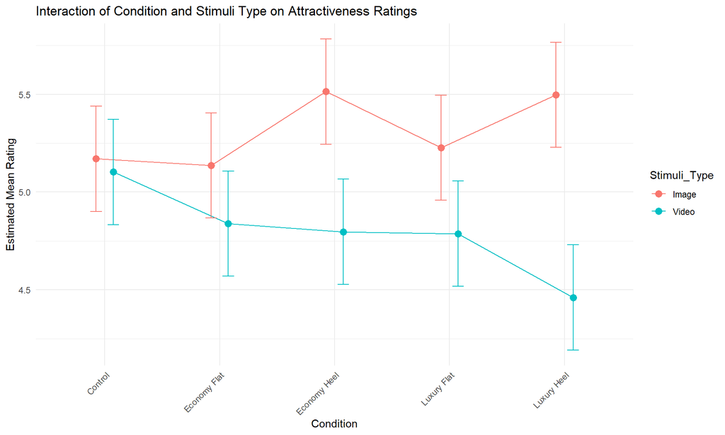

Figure B2.1. Interaction between footwear condition and stimulus type (image vs. video) on attractiveness ratings. Error bars represent 95% confidence intervals.

### Pairwise Comparisons for Condition by Stimuli_Type in Attractiveness Model

```
## Stimuli_Type = Image:
##  contrast                    estimate     SE  df z.ratio p.value
##  Control - Economy Flat       0.03390 0.0507 Inf   0.668  0.9632
##  Control - Economy Heel      -0.34427 0.0507 Inf  -6.789  <.0001
##  Control - Luxury Flat       -0.05657 0.0507 Inf  -1.116  0.7984
##  Control - Luxury Heel       -0.32699 0.0508 Inf  -6.443  <.0001
##  Economy Flat - Economy Heel -0.37818 0.0507 Inf  -7.453  <.0001
##  Economy Flat - Luxury Flat  -0.09047 0.0507 Inf  -1.783  0.3833
##  Economy Flat - Luxury Heel  -0.36089 0.0508 Inf  -7.107  <.0001
##  Economy Heel - Luxury Flat   0.28771 0.0507 Inf   5.674  <.0001
##  Economy Heel - Luxury Heel   0.01729 0.0508 Inf   0.341  0.9971
##  Luxury Flat - Luxury Heel   -0.27042 0.0507 Inf  -5.329  <.0001
##
## Stimuli_Type = Video:
##  contrast                    estimate     SE  df z.ratio p.value
##  Control - Economy Flat       0.26415 0.0507 Inf   5.211  <.0001
##  Control - Economy Heel       0.30567 0.0507 Inf   6.027  <.0001
##  Control - Luxury Flat        0.31504 0.0507 Inf   6.212  <.0001
##  Control - Luxury Heel        0.64189 0.0507 Inf  12.655  <.0001
##  Economy Flat - Economy Heel  0.04153 0.0507 Inf   0.819  0.9249
##  Economy Flat - Luxury Flat   0.05089 0.0507 Inf   1.004  0.8538
##  Economy Flat - Luxury Heel   0.37774 0.0507 Inf   7.448  <.0001
##  Economy Heel - Luxury Flat   0.00936 0.0507 Inf   0.185  0.9997
##  Economy Heel - Luxury Heel   0.33622 0.0507 Inf   6.626  <.0001
##  Luxury Flat - Luxury Heel    0.32685 0.0507 Inf   6.441  <.0001
##
## Degrees-of-freedom method: asymptotic
## P value adjustment: tukey method for comparing a family of 5 estimates
```

## 9. Wealth Model with Interaction

A linear mixed-effects model for wealth was constructed including the interaction between Condition and Stimuli_Type:

```
## Linear mixed model fit by REML. t-tests use Satterthwaite's method [
## lmerModLmerTest]
## Formula: Rating ~ Condition * Stimuli_Type + (1 | block/Model) + (1 |
##     code)
##    Data: body_df_wealth
##
## REML criterion at convergence: 44395.5
##
## Scaled residuals:
##     Min      1Q  Median      3Q     Max
## -4.5286 -0.5751 -0.0159  0.5588  4.7829
##
## Random effects:
##  Groups      Name        Variance Std.Dev.
##  code        (Intercept) 0.8498   0.9218
##  Model:block (Intercept) 0.1943   0.4408
##  block       (Intercept) 0.0000   0.0000
##  Residual                1.4066   1.1860
## Number of obs: 13603, groups:  code, 279; Model:block, 54; block, 11
##
## Fixed effects:
##                                           Estimate Std. Error         df
## (Intercept)                              4.534e+00  8.771e-02  1.841e+02
## ConditionEconomy Flat                    1.946e-01  4.548e-02  1.327e+04
## ConditionEconomy Heel                    7.817e-01  4.548e-02  1.327e+04
## ConditionLuxury Flat                     3.798e-01  4.546e-02  1.327e+04
## ConditionLuxury Heel                     7.965e-01  4.554e-02  1.327e+04
## Stimuli_TypeVideo                       -9.442e-02  4.545e-02  1.327e+04
## ConditionEconomy Flat:Stimuli_TypeVideo  2.230e-02  6.428e-02  1.327e+04
## ConditionEconomy Heel:Stimuli_TypeVideo -7.445e-02  6.431e-02  1.327e+04
## ConditionLuxury Flat:Stimuli_TypeVideo  -2.573e-02  6.428e-02  1.327e+04
## ConditionLuxury Heel:Stimuli_TypeVideo  -3.298e-01  6.434e-02  1.327e+04
##                                         t value Pr(>|t|)
## (Intercept)                              51.690  < 2e-16 ***
## ConditionEconomy Flat                     4.278 1.90e-05 ***
## ConditionEconomy Heel                    17.186  < 2e-16 ***
## ConditionLuxury Flat                      8.355  < 2e-16 ***
## ConditionLuxury Heel                     17.492  < 2e-16 ***
## Stimuli_TypeVideo                        -2.077   0.0378 *
## ConditionEconomy Flat:Stimuli_TypeVideo   0.347   0.7287
## ConditionEconomy Heel:Stimuli_TypeVideo  -1.158   0.2470
## ConditionLuxury Flat:Stimuli_TypeVideo   -0.400   0.6890
## ConditionLuxury Heel:Stimuli_TypeVideo   -5.127 2.99e-07 ***
## ---
## Signif. codes:  0 '***' 0.001 '**' 0.01 '*' 0.05 '.' 0.1 ' ' 1
##
## Correlation of Fixed Effects:
##             (Intr) CndtEF CndtEH CndtLF CndtLH Stm_TV CEF:S_ CEH:S_ CLF:S_
## CndtnEcnmyF -0.259
## CndtnEcnmyH -0.259  0.500
## CndtnLxryFl -0.259  0.500  0.500
## CndtnLxryHl -0.259  0.499  0.499  0.499
## Stiml_TypVd -0.259  0.500  0.500  0.500  0.499
## CndtEF:S_TV  0.183 -0.708 -0.354 -0.354 -0.353 -0.707
## CndtEH:S_TV  0.183 -0.353 -0.707 -0.354 -0.353 -0.707  0.500
## CndtLF:S_TV  0.183 -0.354 -0.354 -0.707 -0.353 -0.707  0.500  0.500
## CndtLH:S_TV  0.183 -0.353 -0.353 -0.353 -0.708 -0.706  0.499  0.499  0.500
## optimizer (nloptwrap) convergence code: 0 (OK)
## boundary (singular) fit: see help('isSingular')
```

### ANOVA for Fixed Effects in Wealth Model with Interaction

```
## Type III Analysis of Variance Table with Satterthwaite's method
##                         Sum Sq Mean Sq NumDF DenDF  F value    Pr(>F)
## Condition              1007.95  251.99     4 13272 179.1457 < 2.2e-16 ***
## Stimuli_Type            105.28  105.28     1 13272  74.8453 < 2.2e-16 ***
## Condition:Stimuli_Type   55.84   13.96     4 13272   9.9248 5.131e-08 ***
## ---
## Signif. codes:  0 '***' 0.001 '**' 0.01 '*' 0.05 '.' 0.1 ' ' 1
```

### Estimated Marginal Means for Condition by Stimuli_Type in Wealth Model

```
## Stimuli_Type = Image:
##  Condition    emmean     SE  df asymp.LCL asymp.UCL
##  Control        4.53 0.0877 Inf      4.36      4.71
##  Economy Flat   4.73 0.0877 Inf      4.56      4.90
##  Economy Heel   5.32 0.0877 Inf      5.14      5.49
##  Luxury Flat    4.91 0.0877 Inf      4.74      5.09
##  Luxury Heel    5.33 0.0877 Inf      5.16      5.50
##
## Stimuli_Type = Video:
##  Condition    emmean     SE  df asymp.LCL asymp.UCL
##  Control        4.44 0.0877 Inf      4.27      4.61
##  Economy Flat   4.66 0.0877 Inf      4.48      4.83
##  Economy Heel   5.15 0.0877 Inf      4.97      5.32
##  Luxury Flat    4.79 0.0877 Inf      4.62      4.97
##  Luxury Heel    4.91 0.0877 Inf      4.73      5.08
##
## Degrees-of-freedom method: asymptotic
## Confidence level used: 0.95
```

### Calculate R-squared values for the wealth model

```
##             R2m       R2c
## [1,] 0.03386218 0.4454785
```

```
## Wealth Model R-squared:
```

```
## R²m (Fixed effects only): 0.0339
```

```
## R²c (Fixed + Random effects): 0.4455
```

```
## Random effects contribution: 0.4116
```

### Visualizing Wealth Results by Condition and Stimuli_Type

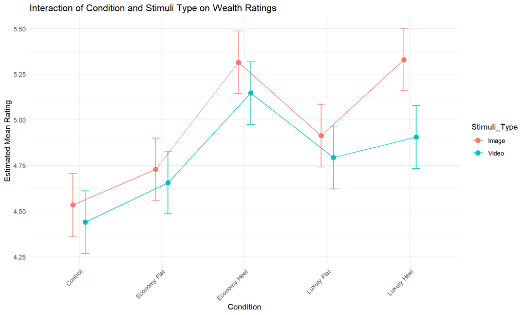

Figure B2.2. Interaction between footwear condition and stimulus type (image vs. video) on wealth perception ratings. Error bars represent 95% confidence intervals.

### Pairwise Comparisons for Condition by Stimuli_Type in Wealth Model

```
## Stimuli_Type = Image:
##  contrast                    estimate     SE  df z.ratio p.value
##  Control - Economy Flat       -0.1946 0.0455 Inf  -4.278  0.0002
##  Control - Economy Heel       -0.7817 0.0455 Inf -17.186  <.0001
##  Control - Luxury Flat        -0.3798 0.0455 Inf  -8.355  <.0001
##  Control - Luxury Heel        -0.7965 0.0455 Inf -17.492  <.0001
##  Economy Flat - Economy Heel  -0.5871 0.0455 Inf -12.903  <.0001
##  Economy Flat - Luxury Flat   -0.1852 0.0455 Inf  -4.073  0.0004
##  Economy Flat - Luxury Heel   -0.6019 0.0456 Inf -13.214  <.0001
##  Economy Heel - Luxury Flat    0.4019 0.0455 Inf   8.837  <.0001
##  Economy Heel - Luxury Heel   -0.0148 0.0456 Inf  -0.325  0.9976
##  Luxury Flat - Luxury Heel    -0.4167 0.0455 Inf  -9.153  <.0001
##
## Stimuli_Type = Video:
##  contrast                    estimate     SE  df z.ratio p.value
##  Control - Economy Flat       -0.2169 0.0454 Inf  -4.774  <.0001
##  Control - Economy Heel       -0.7072 0.0455 Inf -15.555  <.0001
##  Control - Luxury Flat        -0.3541 0.0454 Inf  -7.792  <.0001
##  Control - Luxury Heel        -0.4667 0.0455 Inf -10.267  <.0001
##  Economy Flat - Economy Heel  -0.4904 0.0455 Inf -10.787  <.0001
##  Economy Flat - Luxury Flat   -0.1372 0.0454 Inf  -3.020  0.0213
##  Economy Flat - Luxury Heel   -0.2498 0.0454 Inf  -5.497  <.0001
##  Economy Heel - Luxury Flat    0.3532 0.0455 Inf   7.766  <.0001
##  Economy Heel - Luxury Heel    0.2406 0.0455 Inf   5.289  <.0001
##  Luxury Flat - Luxury Heel    -0.1126 0.0455 Inf  -2.477  0.0958
##
## Degrees-of-freedom method: asymptotic
## P value adjustment: tukey method for comparing a family of 5 estimates
```

## 10. Combined Plot: Condition × Dimension × Stimuli_Type

A combined plot was created to visualize the interaction between Condition, Dimension, and Stimuli_Type:

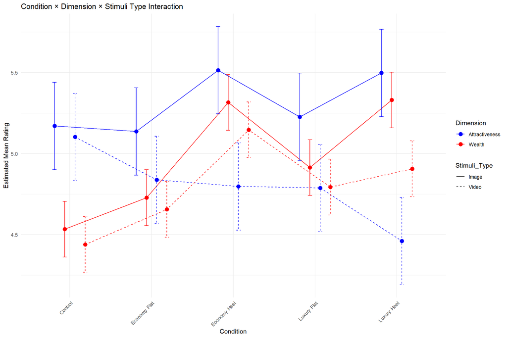

Figure B2.3. Three-way interaction between footwear condition, dimension (attractiveness vs. wealth), and stimulus type. Solid lines represent image stimuli; dashed lines represent video stimuli. Error bars represent 95% confidence intervals.

## **PART III: Supplement B3: Complete models including control condition (Split by StimuliType)**

## 11. Models for Image Stimuli Only

### Attractiveness Model for Image Stimuli

```
## Linear mixed model fit by REML. t-tests use Satterthwaite's method [
## lmerModLmerTest]
## Formula: Rating ~ Condition + (1 | block/Model) + (1 | code)
##    Data: body_df_attract_image
##
## REML criterion at convergence: 22528.6
##
## Scaled residuals:
##     Min      1Q  Median      3Q     Max
## -5.1111 -0.5959 -0.0052  0.5790  4.6063
##
## Random effects:
##  Groups      Name        Variance Std.Dev.
##  code        (Intercept) 1.989    1.4103
##  Model:block (Intercept) 0.677    0.8228
##  block       (Intercept) 0.000    0.0000
##  Residual                1.336    1.1560
## Number of obs: 6814, groups:  code, 279; Model:block, 54; block, 11
##
## Fixed effects:
##                         Estimate Std. Error         df t value Pr(>|t|)
## (Intercept)              5.16903    0.14384  124.06307  35.935  < 2e-16 ***
## ConditionEconomy Flat   -0.03432    0.04429 6487.97626  -0.775    0.438
## ConditionEconomy Heel    0.34415    0.04427 6487.98276   7.774 8.77e-15 ***
## ConditionLuxury Flat     0.05591    0.04426 6487.96655   1.263    0.207
## ConditionLuxury Heel     0.32696    0.04430 6487.99434   7.380 1.78e-13 ***
## ---
## Signif. codes:  0 '***' 0.001 '**' 0.01 '*' 0.05 '.' 0.1 ' ' 1
##
## Correlation of Fixed Effects:
##             (Intr) CndtEF CndtEH CndtLF
## CndtnEcnmyF -0.154
## CndtnEcnmyH -0.154  0.500
## CndtnLxryFl -0.154  0.500  0.500
## CndtnLxryHl -0.154  0.499  0.500  0.500
## optimizer (nloptwrap) convergence code: 0 (OK)
## boundary (singular) fit: see help('isSingular')
```

### ANOVA for Fixed Effects in Attractiveness Model (Image Stimuli)

```
## Type III Analysis of Variance Table with Satterthwaite's method
##           Sum Sq Mean Sq NumDF DenDF F value    Pr(>F)
## Condition 182.09  45.522     4  6488  34.065 < 2.2e-16 ***
## ---
## Signif. codes:  0 '***' 0.001 '**' 0.01 '*' 0.05 '.' 0.1 ' ' 1
```

### Estimated Marginal Means for Condition in Attractiveness Model (Image Stimuli)

```
##  Condition    emmean    SE  df asymp.LCL asymp.UCL
##  Control        5.17 0.144 Inf      4.89      5.45
##  Economy Flat   5.13 0.144 Inf      4.85      5.42
##  Economy Heel   5.51 0.144 Inf      5.23      5.80
##  Luxury Flat    5.22 0.144 Inf      4.94      5.51
##  Luxury Heel    5.50 0.144 Inf      5.21      5.78
##
## Degrees-of-freedom method: asymptotic
## Confidence level used: 0.95
```

### Calculate R-squared values for the attractiveness model

```
##              R2m       R2c
## [1,] 0.006634421 0.6683305
```

```
## Attractiveness Model R-squared:
```

```
## R²m (Fixed effects only): 0.0066
```

```
## R²c (Fixed + Random effects): 0.6683
```

```
## Random effects contribution: 0.6617
```

### Visualizing Attractiveness Results for Image Stimuli

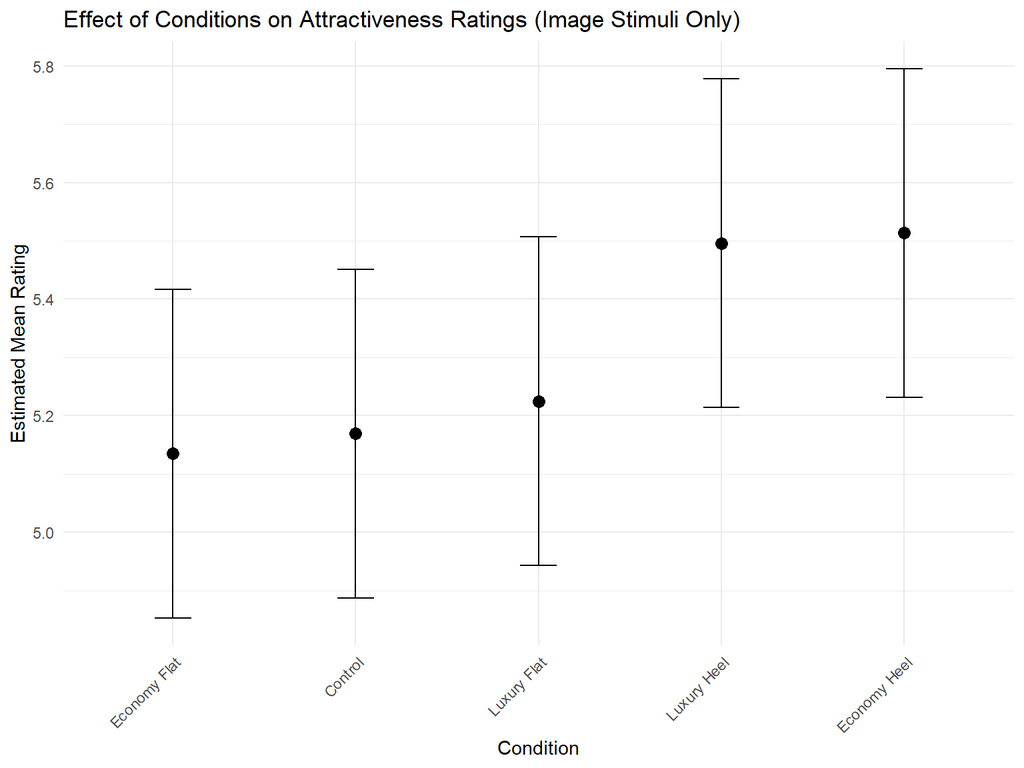

Figure B3.1. Effect of footwear conditions on attractiveness ratings for image stimuli, including control condition. Error bars represent 95% confidence intervals.

### Pairwise Comparisons for Condition in Attractiveness Model (Image Stimuli)

```
##  contrast                    estimate     SE  df z.ratio p.value
##  Control - Economy Flat        0.0343 0.0443 Inf   0.775  0.9379
##  Control - Economy Heel       -0.3442 0.0443 Inf  -7.774  <.0001
##  Control - Luxury Flat        -0.0559 0.0443 Inf  -1.263  0.7138
##  Control - Luxury Heel        -0.3270 0.0443 Inf  -7.380  <.0001
##  Economy Flat - Economy Heel  -0.3785 0.0443 Inf  -8.545  <.0001
##  Economy Flat - Luxury Flat   -0.0902 0.0443 Inf  -2.038  0.2480
##  Economy Flat - Luxury Heel   -0.3613 0.0443 Inf  -8.150  <.0001
##  Economy Heel - Luxury Flat    0.2882 0.0443 Inf   6.512  <.0001
##  Economy Heel - Luxury Heel    0.0172 0.0443 Inf   0.388  0.9952
##  Luxury Flat - Luxury Heel    -0.2711 0.0443 Inf  -6.119  <.0001
##
## Degrees-of-freedom method: asymptotic
## P value adjustment: tukey method for comparing a family of 5 estimates
```

### Wealth Model for Image Stimuli

```
## Linear mixed model fit by REML. t-tests use Satterthwaite's method [
## lmerModLmerTest]
## Formula: Rating ~ Condition + (1 | block/Model) + (1 | code)
##    Data: body_df_wealth_image
##
## REML criterion at convergence: 20811.7
##
## Scaled residuals:
##     Min      1Q  Median      3Q     Max
## -5.0202 -0.5717 -0.0140  0.5552  4.4834
##
## Random effects:
##  Groups      Name        Variance  Std.Dev.
##  code        (Intercept) 9.403e-01 9.697e-01
##  Model:block (Intercept) 1.935e-01 4.399e-01
##  block       (Intercept) 1.581e-09 3.976e-05
##  Residual                1.077e+00 1.038e+00
## Number of obs: 6794, groups:  code, 279; Model:block, 54; block, 11
##
## Fixed effects:
##                        Estimate Std. Error        df t value Pr(>|t|)
## (Intercept)           4.532e+00  8.810e-02 1.798e+02  51.442  < 2e-16 ***
## ConditionEconomy Flat 1.939e-01  3.980e-02 6.468e+03   4.872 1.13e-06 ***
## ConditionEconomy Heel 7.818e-01  3.981e-02 6.468e+03  19.641  < 2e-16 ***
## ConditionLuxury Flat  3.785e-01  3.978e-02 6.468e+03   9.515  < 2e-16 ***
## ConditionLuxury Heel  7.979e-01  3.985e-02 6.468e+03  20.023  < 2e-16 ***
## ---
## Signif. codes:  0 '***' 0.001 '**' 0.01 '*' 0.05 '.' 0.1 ' ' 1
##
## Correlation of Fixed Effects:
##             (Intr) CndtEF CndtEH CndtLF
## CndtnEcnmyF -0.226
## CndtnEcnmyH -0.226  0.500
## CndtnLxryFl -0.226  0.500  0.500
## CndtnLxryHl -0.225  0.499  0.499  0.499
## optimizer (nloptwrap) convergence code: 0 (OK)
## boundary (singular) fit: see help('isSingular')
```

### ANOVA for Fixed Effects in Wealth Model (Image Stimuli)

```
## Type III Analysis of Variance Table with Satterthwaite's method
##           Sum Sq Mean Sq NumDF  DenDF F value    Pr(>F)
## Condition 682.14  170.54     4 6468.1  158.32 < 2.2e-16 ***
## ---
## Signif. codes:  0 '***' 0.001 '**' 0.01 '*' 0.05 '.' 0.1 ' ' 1
```

### Estimated Marginal Means for Condition in Wealth Model (Image Stimuli)

```
##  Condition    emmean     SE  df asymp.LCL asymp.UCL
##  Control        4.53 0.0881 Inf      4.36      4.70
##  Economy Flat   4.73 0.0881 Inf      4.55      4.90
##  Economy Heel   5.31 0.0881 Inf      5.14      5.49
##  Luxury Flat    4.91 0.0881 Inf      4.74      5.08
##  Luxury Heel    5.33 0.0881 Inf      5.16      5.50
##
## Degrees-of-freedom method: asymptotic
## Confidence level used: 0.95
```

### Calculate R-squared values for the wealth model

```
##             R2m       R2c
## [1,] 0.04345892 0.5339808
```

```
## Wealth Model R-squared:
```

```
## R²m (Fixed effects only): 0.0435
```

```
## R²c (Fixed + Random effects): 0.534
```

```
## Random effects contribution: 0.4905
```

### Visualizing Wealth Results for Image Stimuli

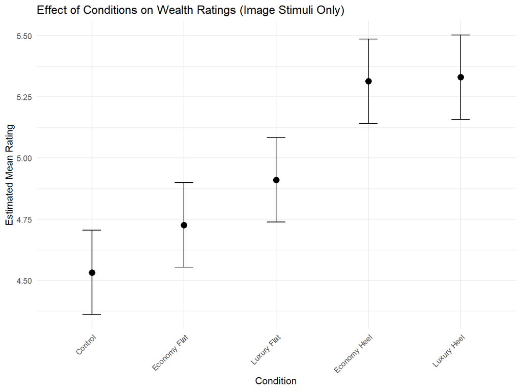

Figure B3.2. Effect of footwear conditions on wealth perception ratings for image stimuli, including control condition. Error bars represent 95% confidence intervals.

### Pairwise Comparisons for Condition in Wealth Model (Image Stimuli)

```
##  contrast                    estimate     SE  df z.ratio p.value
##  Control - Economy Flat       -0.1939 0.0398 Inf  -4.872  <.0001
##  Control - Economy Heel       -0.7818 0.0398 Inf -19.641  <.0001
##  Control - Luxury Flat        -0.3785 0.0398 Inf  -9.515  <.0001
##  Control - Luxury Heel        -0.7979 0.0399 Inf -20.023  <.0001
##  Economy Flat - Economy Heel  -0.5879 0.0398 Inf -14.763  <.0001
##  Economy Flat - Luxury Flat   -0.1846 0.0398 Inf  -4.638  <.0001
##  Economy Flat - Luxury Heel   -0.6040 0.0399 Inf -15.151  <.0001
##  Economy Heel - Luxury Flat    0.4033 0.0398 Inf  10.133  <.0001
##  Economy Heel - Luxury Heel   -0.0161 0.0399 Inf  -0.404  0.9944
##  Luxury Flat - Luxury Heel    -0.4194 0.0398 Inf -10.526  <.0001
##
## Degrees-of-freedom method: asymptotic
## P value adjustment: tukey method for comparing a family of 5 estimates
```

### Comparison Between Dimensions for Image Stimuli

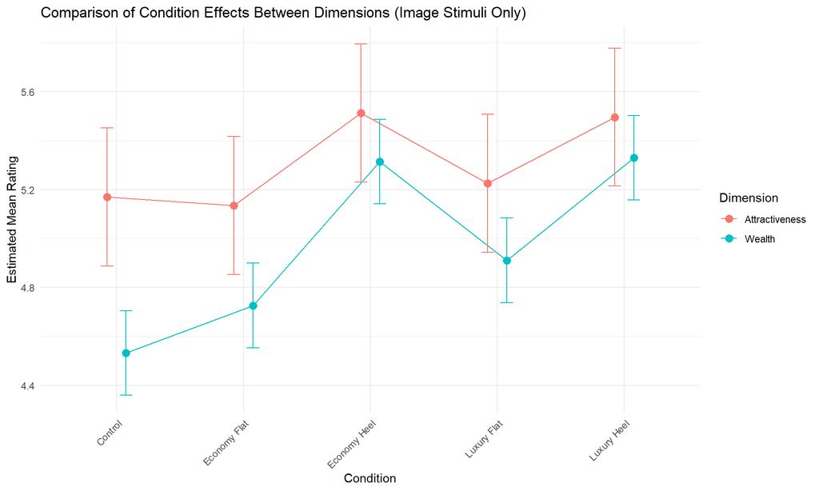

Figure B3.3. Comparison of footwear condition effects between attractiveness and wealth dimensions for image stimuli. Error bars represent 95% confidence intervals.

## 12. Models for Video Stimuli Only

Next, the data was filtered to include only Video stimuli:

### Attractiveness Model for Video Stimuli

```
## Linear mixed model fit by REML. t-tests use Satterthwaite's method [
## lmerModLmerTest]
## Formula: Rating ~ Condition + (1 | block/Model) + (1 | code)
##    Data: body_df_attract_video
##
## REML criterion at convergence: 24118.3
##
## Scaled residuals:
##     Min      1Q  Median      3Q     Max
## -5.1941 -0.6264 -0.0367  0.6031  4.0194
##
## Random effects:
##  Groups      Name        Variance Std.Dev.
##  code        (Intercept) 1.7047   1.3057
##  Model:block (Intercept) 0.7812   0.8838
##  block       (Intercept) 0.0000   0.0000
##  Residual                1.7111   1.3081
## Number of obs: 6819, groups:  code, 279; Model:block, 54; block, 11
##
## Fixed effects:
##                         Estimate Std. Error         df t value Pr(>|t|)
## (Intercept)              5.10366    0.14789  105.10690  34.510  < 2e-16 ***
## ConditionEconomy Flat   -0.26387    0.05006 6493.10837  -5.271 1.40e-07 ***
## ConditionEconomy Heel   -0.30457    0.05009 6493.13615  -6.080 1.27e-09 ***
## ConditionLuxury Flat    -0.31447    0.05009 6493.11634  -6.278 3.65e-10 ***
## ConditionLuxury Heel    -0.64010    0.05010 6493.16374 -12.776  < 2e-16 ***
## ---
## Signif. codes:  0 '***' 0.001 '**' 0.01 '*' 0.05 '.' 0.1 ' ' 1
##
## Correlation of Fixed Effects:
##             (Intr) CndtEF CndtEH CndtLF
## CndtnEcnmyF -0.169
## CndtnEcnmyH -0.169  0.500
## CndtnLxryFl -0.169  0.500  0.500
## CndtnLxryHl -0.169  0.500  0.500  0.500
## optimizer (nloptwrap) convergence code: 0 (OK)
## boundary (singular) fit: see help('isSingular')
```

### ANOVA for Fixed Effects in Attractiveness Model (Video Stimuli)

```
## Type III Analysis of Variance Table with Satterthwaite's method
##           Sum Sq Mean Sq NumDF  DenDF F value    Pr(>F)
## Condition  282.3  70.576     4 6493.1  41.246 < 2.2e-16 ***
## ---
## Signif. codes:  0 '***' 0.001 '**' 0.01 '*' 0.05 '.' 0.1 ' ' 1
```

### Estimated Marginal Means for Condition in Attractiveness Model (Video Stimuli)

```
##  Condition    emmean    SE  df asymp.LCL asymp.UCL
##  Control        5.10 0.148 Inf      4.81      5.39
##  Economy Flat   4.84 0.148 Inf      4.55      5.13
##  Economy Heel   4.80 0.148 Inf      4.51      5.09
##  Luxury Flat    4.79 0.148 Inf      4.50      5.08
##  Luxury Heel    4.46 0.148 Inf      4.17      4.75
##
## Degrees-of-freedom method: asymptotic
## Confidence level used: 0.95
```

### Calculate R-squared values for the attractiveness model

```
##              R2m       R2c
## [1,] 0.009771014 0.5962899
```

```
## Attractiveness Model R-squared:
```

```
## R²m (Fixed effects only): 0.0098
```

```
## R²c (Fixed + Random effects): 0.5963
```

```
## Random effects contribution: 0.5865
```

### Visualizing Attractiveness Results for Video Stimuli

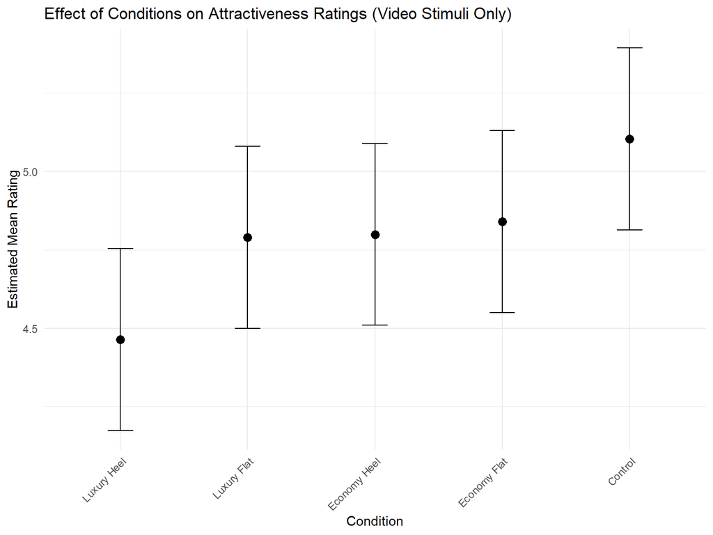

Figure B3.4. Effect of footwear conditions on attractiveness ratings for video stimuli, including control condition. Error bars represent 95% confidence intervals.

### Pairwise Comparisons for Condition in Attractiveness Model (Video Stimuli)

```
##  contrast                    estimate     SE  df z.ratio p.value
##  Control - Economy Flat        0.2639 0.0501 Inf   5.271  <.0001
##  Control - Economy Heel        0.3046 0.0501 Inf   6.080  <.0001
##  Control - Luxury Flat         0.3145 0.0501 Inf   6.278  <.0001
##  Control - Luxury Heel         0.6401 0.0501 Inf  12.776  <.0001
##  Economy Flat - Economy Heel   0.0407 0.0501 Inf   0.813  0.9269
##  Economy Flat - Luxury Flat    0.0506 0.0501 Inf   1.010  0.8508
##  Economy Flat - Luxury Heel    0.3762 0.0501 Inf   7.511  <.0001
##  Economy Heel - Luxury Flat    0.0099 0.0501 Inf   0.198  0.9997
##  Economy Heel - Luxury Heel    0.3355 0.0501 Inf   6.695  <.0001
##  Luxury Flat - Luxury Heel     0.3256 0.0501 Inf   6.497  <.0001
##
## Degrees-of-freedom method: asymptotic
## P value adjustment: tukey method for comparing a family of 5 estimates
```

### Wealth Model for Video Stimuli

```
## Linear mixed model fit by REML. t-tests use Satterthwaite's method [
## lmerModLmerTest]
## Formula: Rating ~ Condition + (1 | block/Model) + (1 | code)
##    Data: body_df_wealth_video
##
## REML criterion at convergence: 23072.6
##
## Scaled residuals:
##     Min      1Q  Median      3Q     Max
## -4.1828 -0.5862 -0.0153  0.5623  4.9834
##
## Random effects:
##  Groups      Name        Variance  Std.Dev.
##  code        (Intercept) 8.905e-01 0.9436448
##  Model:block (Intercept) 2.990e-01 0.5468359
##  block       (Intercept) 2.930e-08 0.0001712
##  Residual                1.513e+00 1.2301948
## Number of obs: 6809, groups:  code, 279; Model:block, 54; block, 11
##
## Fixed effects:
##                        Estimate Std. Error        df t value Pr(>|t|)
## (Intercept)           4.441e+00  9.930e-02 1.345e+02  44.725  < 2e-16 ***
## ConditionEconomy Flat 2.167e-01  4.712e-02 6.483e+03   4.600 4.31e-06 ***
## ConditionEconomy Heel 7.067e-01  4.716e-02 6.483e+03  14.984  < 2e-16 ***
## ConditionLuxury Flat  3.533e-01  4.714e-02 6.483e+03   7.495 7.52e-14 ***
## ConditionLuxury Heel  4.671e-01  4.715e-02 6.483e+03   9.906  < 2e-16 ***
## ---
## Signif. codes:  0 '***' 0.001 '**' 0.01 '*' 0.05 '.' 0.1 ' ' 1
##
## Correlation of Fixed Effects:
##             (Intr) CndtEF CndtEH CndtLF
## CndtnEcnmyF -0.237
## CndtnEcnmyH -0.237  0.500
## CndtnLxryFl -0.237  0.500  0.500
## CndtnLxryHl -0.237  0.500  0.499  0.500
```

### ANOVA for Fixed Effects in Wealth Model (Video Stimuli)

```
## Type III Analysis of Variance Table with Satterthwaite's method
##           Sum Sq Mean Sq NumDF  DenDF F value    Pr(>F)
## Condition 382.66  95.666     4 6483.3  63.213 < 2.2e-16 ***
## ---
## Signif. codes:  0 '***' 0.001 '**' 0.01 '*' 0.05 '.' 0.1 ' ' 1
```

### Estimated Marginal Means for Condition in Wealth Model (Video Stimuli)

```
##  Condition    emmean     SE  df asymp.LCL asymp.UCL
##  Control        4.44 0.0993 Inf      4.25      4.64
##  Economy Flat   4.66 0.0993 Inf      4.46      4.85
##  Economy Heel   5.15 0.0993 Inf      4.95      5.34
##  Luxury Flat    4.79 0.0993 Inf      4.60      4.99
##  Luxury Heel    4.91 0.0993 Inf      4.71      5.10
##
## Degrees-of-freedom method: asymptotic
## Confidence level used: 0.95
```

### Calculate R-squared values for the wealth model

```
##            R2m       R2c
## [1,] 0.0203768 0.4514945
```

```
## Wealth Model R-squared:
```

```
## R²m (Fixed effects only): 0.0204
```

```
## R²c (Fixed + Random effects): 0.4515
```

```
## Random effects contribution: 0.4311
```

### Visualizing Wealth Results for Video Stimuli

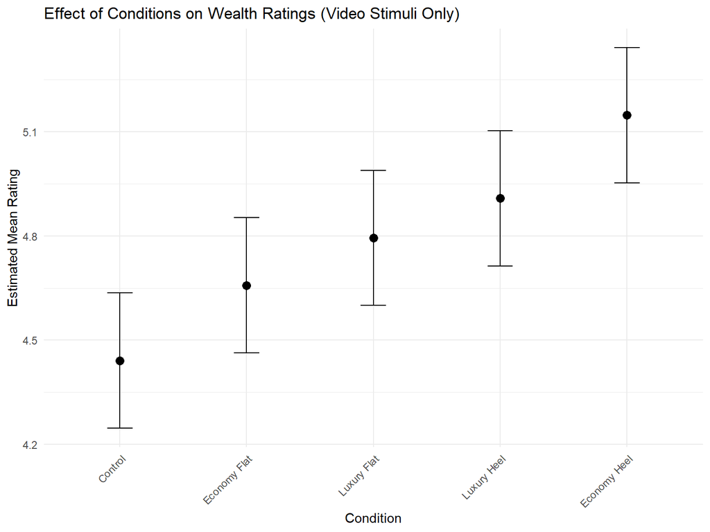

Figure B3.5. Effect of footwear conditions on wealth perception ratings for video stimuli, including control condition. Error bars represent 95% confidence intervals.

### Pairwise Comparisons for Condition in Wealth Model (Video Stimuli)

```
##  contrast                    estimate     SE  df z.ratio p.value
##  Control - Economy Flat        -0.217 0.0471 Inf  -4.600  <.0001
##  Control - Economy Heel        -0.707 0.0472 Inf -14.984  <.0001
##  Control - Luxury Flat         -0.353 0.0471 Inf  -7.495  <.0001
##  Control - Luxury Heel         -0.467 0.0471 Inf  -9.906  <.0001
##  Economy Flat - Economy Heel   -0.490 0.0472 Inf -10.391  <.0001
##  Economy Flat - Luxury Flat    -0.137 0.0471 Inf  -2.897  0.0308
##  Economy Flat - Luxury Heel    -0.250 0.0471 Inf  -5.311  <.0001
##  Economy Heel - Luxury Flat     0.353 0.0472 Inf   7.492  <.0001
##  Economy Heel - Luxury Heel     0.240 0.0472 Inf   5.079  <.0001
##  Luxury Flat - Luxury Heel     -0.114 0.0472 Inf  -2.413  0.1118
##
## Degrees-of-freedom method: asymptotic
## P value adjustment: tukey method for comparing a family of 5 estimates
```

### Comparison Between Dimensions for Video Stimuli

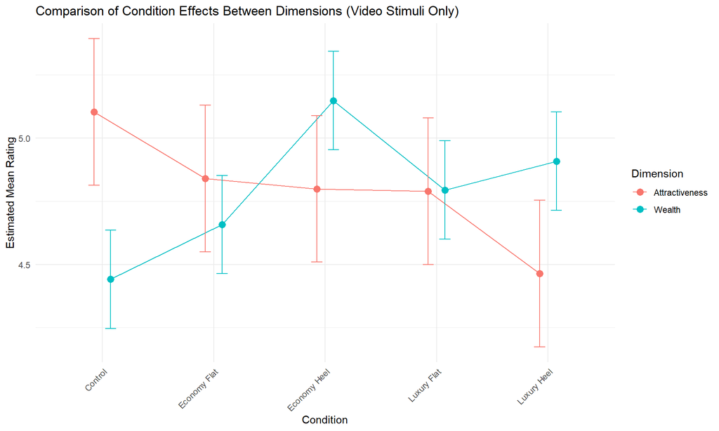

Figure B3.6. Comparison of footwear condition effects between attractiveness and wealth dimensions for video stimuli. Error bars represent 95% confidence intervals.

Creating comparison plot for Dimention x StimuliType

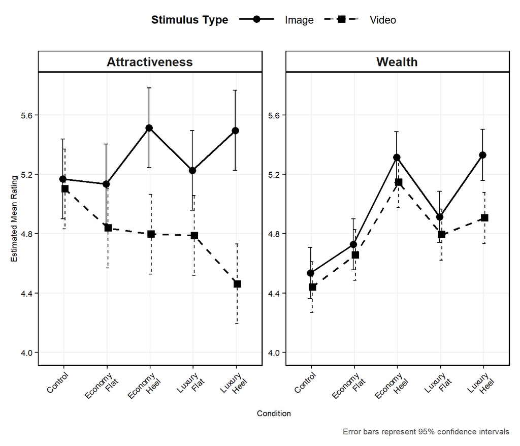

Figure B3.7. Comparison of footwear condition effects across stimulus types (image vs. video) and dimensions (attractiveness vs. wealth). Error bars represent 95% confidence intervals.

## **PART IV: Supplement B4: 2×2 Factorial Analysis (Excluding Control Condition)**

## 13. Data Preparation for 2×2 Factorial Design

## 14. Attractiveness Models - 2×2 Factorial Design

### 14.1 Attractiveness Model for Image Stimuli (2×2)

```
## Linear mixed model fit by REML. t-tests use Satterthwaite's method [
## lmerModLmerTest]
## Formula: Rating ~ Trait_Exaggeration * Cost + (1 | block/Model) + (1 |
##     code)
##    Data: body_df_attract_factorial_image
##
## REML criterion at convergence: 18152.7
##
## Scaled residuals:
##     Min      1Q  Median      3Q     Max
## -5.1205 -0.5987 -0.0033  0.5779  4.2893
##
## Random effects:
##  Groups      Name        Variance Std.Dev.
##  code        (Intercept) 2.0089   1.4173
##  Model:block (Intercept) 0.6718   0.8196
##  block       (Intercept) 0.0000   0.0000
##  Residual                1.3251   1.1511
## Number of obs: 5450, groups:  code, 279; Model:block, 54; block, 11
##
## Fixed effects:
##                             Estimate Std. Error         df t value Pr(>|t|)
## (Intercept)                  5.34189    0.14117  115.86546  37.840   <2e-16 ***
## Trait_Exaggeration1         -0.16251    0.01559 5124.96037 -10.421   <2e-16 ***
## Cost1                       -0.01816    0.01559 5124.98257  -1.164   0.2443
## Trait_Exaggeration1:Cost1   -0.02705    0.01559 5124.97924  -1.734   0.0829 .
## ---
## Signif. codes:  0 '***' 0.001 '**' 0.01 '*' 0.05 '.' 0.1 ' ' 1
##
## Correlation of Fixed Effects:
##             (Intr) Trt_E1 Cost1
## Trt_Exggrt1 0.000
## Cost1       0.000  0.002
## Trt_Exg1:C1 0.000  0.000  0.000
## optimizer (nloptwrap) convergence code: 0 (OK)
## boundary (singular) fit: see help('isSingular')
```

ANOVA for 2×2 Factorial Model (Attractiveness - Image)

```
## Type III Analysis of Variance Table with Satterthwaite's method
##                          Sum Sq Mean Sq NumDF DenDF  F value Pr(>F)
## Trait_Exaggeration      143.904 143.904     1  5125 108.6011 <2e-16 ***
## Cost                      1.797   1.797     1  5125   1.3560 0.2443
## Trait_Exaggeration:Cost   3.986   3.986     1  5125   3.0083 0.0829 .
## ---
## Signif. codes:  0 '***' 0.001 '**' 0.01 '*' 0.05 '.' 0.1 ' ' 1
```

Estimated Marginal Means (Attractiveness - Image)

```
## [1] "Main Effect of Trait Exaggeration:"
```

```
##  Trait_Exaggeration emmean    SE  df asymp.LCL asymp.UCL
##  Flat                 5.18 0.142 Inf      4.90      5.46
##  Heel                 5.50 0.142 Inf      5.23      5.78
##
## Results are averaged over the levels of: Cost
## Degrees-of-freedom method: asymptotic
## Confidence level used: 0.95
```

```
## [1] "Main Effect of Cost:"
```

```
##  Cost    emmean    SE  df asymp.LCL asymp.UCL
##  Economy   5.32 0.142 Inf      5.05      5.60
##  Luxury    5.36 0.142 Inf      5.08      5.64
##
## Results are averaged over the levels of: Trait_Exaggeration
## Degrees-of-freedom method: asymptotic
## Confidence level used: 0.95
```

```
## [1] "Interaction: Trait Exaggeration × Cost:"
```

```
## Cost = Economy:
##  Trait_Exaggeration emmean    SE  df asymp.LCL asymp.UCL
##  Flat                 5.13 0.144 Inf      4.85      5.42
##  Heel                 5.51 0.144 Inf      5.23      5.79
##
## Cost = Luxury:
##  Trait_Exaggeration emmean    SE  df asymp.LCL asymp.UCL
##  Flat                 5.22 0.144 Inf      4.94      5.51
##  Heel                 5.50 0.144 Inf      5.21      5.78
##
## Degrees-of-freedom method: asymptotic
## Confidence level used: 0.95
```

Pairwise Comparisons (Attractiveness - Image)

```
## Cost = Economy:
##  contrast    estimate     SE  df z.ratio p.value
##  Flat - Heel   -0.379 0.0441 Inf  -8.595  <.0001
##
## Cost = Luxury:
##  contrast    estimate     SE  df z.ratio p.value
##  Flat - Heel   -0.271 0.0441 Inf  -6.142  <.0001
##
## Degrees-of-freedom method: asymptotic
```

```
## Trait_Exaggeration = Flat:
##  contrast         estimate     SE  df z.ratio p.value
##  Economy - Luxury  -0.0904 0.0441 Inf  -2.050  0.0403
##
## Trait_Exaggeration = Heel:
##  contrast         estimate     SE  df z.ratio p.value
##  Economy - Luxury   0.0178 0.0441 Inf   0.403  0.6870
##
## Degrees-of-freedom method: asymptotic
```

R-squared for Attractiveness Model (Image - 2×2)

```
##              R2m       R2c
## [1,] 0.006810238 0.6714619
```

```
## Attractiveness Model (Image) R-squared:
```

```
## R²m (Fixed effects only): 0.0068
```

```
## R²c (Fixed + Random effects): 0.6715
```

```
## Random effects contribution: 0.6647
```

### 14.2 Attractiveness Model for Video Stimuli (2×2)

```
## Linear mixed model fit by REML. t-tests use Satterthwaite's method [
## lmerModLmerTest]
## Formula: Rating ~ Trait_Exaggeration * Cost + (1 | block/Model) + (1 |
##     code)
##    Data: body_df_attract_factorial_video
##
## REML criterion at convergence: 19364.4
##
## Scaled residuals:
##     Min      1Q  Median      3Q     Max
## -3.6732 -0.6332 -0.0364  0.6063  3.8647
##
## Random effects:
##  Groups      Name        Variance Std.Dev.
##  code        (Intercept) 1.7309   1.3157
##  Model:block (Intercept) 0.7686   0.8767
##  block       (Intercept) 0.0000   0.0000
##  Residual                1.6837   1.2976
## Number of obs: 5454, groups:  code, 279; Model:block, 54; block, 11
##
## Fixed effects:
##                             Estimate Std. Error         df t value Pr(>|t|)
## (Intercept)                  4.72322    0.14418   96.83055  32.759  < 2e-16 ***
## Trait_Exaggeration1          0.09129    0.01757 5129.22221   5.195 2.12e-07 ***
## Cost1                        0.09629    0.01757 5129.18611   5.480 4.45e-08 ***
## Trait_Exaggeration1:Cost1   -0.07103    0.01757 5129.16713  -4.042 5.37e-05 ***
## ---
## Signif. codes:  0 '***' 0.001 '**' 0.01 '*' 0.05 '.' 0.1 ' ' 1
##
## Correlation of Fixed Effects:
##             (Intr) Trt_E1 Cost1
## Trt_Exggrt1  0.000
## Cost1        0.000  0.000
## Trt_Exg1:C1  0.000 -0.001 -0.001
## optimizer (nloptwrap) convergence code: 0 (OK)
## boundary (singular) fit: see help('isSingular')
```

ANOVA for 2×2 Factorial Model (Attractiveness - Video)

```
## Type III Analysis of Variance Table with Satterthwaite's method
##                         Sum Sq Mean Sq NumDF  DenDF F value    Pr(>F)
## Trait_Exaggeration      45.445  45.445     1 5129.2  26.992 2.122e-07 ***
## Cost                    50.564  50.564     1 5129.2  30.032 4.453e-08 ***
## Trait_Exaggeration:Cost 27.514  27.514     1 5129.2  16.342 5.367e-05 ***
## ---
## Signif. codes:  0 '***' 0.001 '**' 0.01 '*' 0.05 '.' 0.1 ' ' 1
```

Estimated Marginal Means (Attractiveness - Video)

```
## [1] "Main Effect of Trait Exaggeration:"
```

```
##  Trait_Exaggeration emmean    SE  df asymp.LCL asymp.UCL
##  Flat                 4.81 0.145 Inf      4.53      5.10
##  Heel                 4.63 0.145 Inf      4.35      4.92
##
## Results are averaged over the levels of: Cost
## Degrees-of-freedom method: asymptotic
## Confidence level used: 0.95
```

```
## [1] "Main Effect of Cost:"
```

```
##  Cost    emmean    SE  df asymp.LCL asymp.UCL
##  Economy   4.82 0.145 Inf      4.53      5.10
##  Luxury    4.63 0.145 Inf      4.34      4.91
##
## Results are averaged over the levels of: Trait_Exaggeration
## Degrees-of-freedom method: asymptotic
## Confidence level used: 0.95
```

```
## [1] "Interaction: Trait Exaggeration × Cost:"
```

```
## Cost = Economy:
##  Trait_Exaggeration emmean    SE  df asymp.LCL asymp.UCL
##  Flat                 4.84 0.147 Inf      4.55      5.13
##  Heel                 4.80 0.147 Inf      4.51      5.09
##
## Cost = Luxury:
##  Trait_Exaggeration emmean    SE  df asymp.LCL asymp.UCL
##  Flat                 4.79 0.147 Inf      4.50      5.08
##  Heel                 4.46 0.147 Inf      4.18      4.75
##
## Degrees-of-freedom method: asymptotic
## Confidence level used: 0.95
```

Pairwise Comparisons (Attractiveness - Video)

```
## Cost = Economy:
##  contrast    estimate     SE  df z.ratio p.value
##  Flat - Heel   0.0405 0.0497 Inf   0.816  0.4146
##
## Cost = Luxury:
##  contrast    estimate     SE  df z.ratio p.value
##  Flat - Heel   0.3247 0.0497 Inf   6.530  <.0001
##
## Degrees-of-freedom method: asymptotic
```

```
## Trait_Exaggeration = Flat:
##  contrast         estimate     SE  df z.ratio p.value
##  Economy - Luxury   0.0505 0.0497 Inf   1.017  0.3091
##
## Trait_Exaggeration = Heel:
##  contrast         estimate     SE  df z.ratio p.value
##  Economy - Luxury   0.3347 0.0497 Inf   6.731  <.0001
##
## Degrees-of-freedom method: asymptotic
```

R-squared for Attractiveness Model (Video - 2×2)

```
##             R2m       R2c
## [1,] 0.00538388 0.5996845
```

```
## Attractiveness Model (Video) R-squared:
```

```
## R²m (Fixed effects only): 0.0054
```

```
## R²c (Fixed + Random effects): 0.5997
```

```
## Random effects contribution: 0.5943
```

## 15. Wealth Models - 2×2 Factorial Design

### 15.1 Wealth Model for Image Stimuli (2×2)

```
## Linear mixed model fit by REML. t-tests use Satterthwaite's method [
## lmerModLmerTest]
## Formula: Rating ~ Trait_Exaggeration * Cost + (1 | block/Model) + (1 |
##     code)
##    Data: body_df_wealth_factorial_image
##
## REML criterion at convergence: 16675.1
##
## Scaled residuals:
##     Min      1Q  Median      3Q     Max
## -4.4860 -0.5730 -0.0212  0.5351  4.3410
##
## Random effects:
##  Groups      Name        Variance Std.Dev.
##  code        (Intercept) 0.9865   0.9932
##  Model:block (Intercept) 0.1999   0.4471
##  block       (Intercept) 0.0000   0.0000
##  Residual                1.0522   1.0258
## Number of obs: 5433, groups:  code, 279; Model:block, 54; block, 11
##
## Fixed effects:
##                             Estimate Std. Error         df t value Pr(>|t|)
## (Intercept)                  5.07080    0.08631  152.09956  58.752  < 2e-16 ***
## Trait_Exaggeration1         -0.25202    0.01392 5108.06769 -18.106  < 2e-16 ***
## Cost1                       -0.05004    0.01392 5108.09220  -3.595 0.000327 ***
## Trait_Exaggeration1:Cost1   -0.04224    0.01392 5108.11232  -3.035 0.002419 **
## ---
## Signif. codes:  0 '***' 0.001 '**' 0.01 '*' 0.05 '.' 0.1 ' ' 1
##
## Correlation of Fixed Effects:
##             (Intr) Trt_E1 Cost1
## Trt_Exggrt1  0.000
## Cost1        0.000  0.002
## Trt_Exg1:C1  0.000 -0.001 -0.002
## optimizer (nloptwrap) convergence code: 0 (OK)
## boundary (singular) fit: see help('isSingular')
```

ANOVA for 2×2 Factorial Model (Wealth - Image)

```
## Type III Analysis of Variance Table with Satterthwaite's method
##                         Sum Sq Mean Sq NumDF  DenDF  F value    Pr(>F)
## Trait_Exaggeration      344.94  344.94     1 5108.1 327.8235 < 2.2e-16 ***
## Cost                     13.60   13.60     1 5108.1  12.9243 0.0003274 ***
## Trait_Exaggeration:Cost   9.69    9.69     1 5108.1   9.2104 0.0024186 **
## ---
## Signif. codes:  0 '***' 0.001 '**' 0.01 '*' 0.05 '.' 0.1 ' ' 1
```

Estimated Marginal Means (Wealth - Image)

```
## [1] "Main Effect of Trait Exaggeration:"
```

```
##  Trait_Exaggeration emmean     SE  df asymp.LCL asymp.UCL
##  Flat                 4.82 0.0874 Inf      4.65      4.99
##  Heel                 5.32 0.0874 Inf      5.15      5.49
##
## Results are averaged over the levels of: Cost
## Degrees-of-freedom method: asymptotic
## Confidence level used: 0.95
```

```
## [1] "Main Effect of Cost:"
```

```
##  Cost    emmean     SE  df asymp.LCL asymp.UCL
##  Economy   5.02 0.0874 Inf      4.85      5.19
##  Luxury    5.12 0.0874 Inf      4.95      5.29
##
## Results are averaged over the levels of: Trait_Exaggeration
## Degrees-of-freedom method: asymptotic
## Confidence level used: 0.95
```

```
## [1] "Interaction: Trait Exaggeration × Cost:"
```

```
## Cost = Economy:
##  Trait_Exaggeration emmean     SE  df asymp.LCL asymp.UCL
##  Flat                 4.73 0.0896 Inf      4.55      4.90
##  Heel                 5.32 0.0896 Inf      5.14      5.49
##
## Cost = Luxury:
##  Trait_Exaggeration emmean     SE  df asymp.LCL asymp.UCL
##  Flat                 4.91 0.0896 Inf      4.74      5.09
##  Heel                 5.33 0.0896 Inf      5.15      5.51
##
## Degrees-of-freedom method: asymptotic
## Confidence level used: 0.95
```

Pairwise Comparisons (Wealth - Image)

```
## Cost = Economy:
##  contrast    estimate     SE  df z.ratio p.value
##  Flat - Heel   -0.589 0.0394 Inf -14.953  <.0001
##
## Cost = Luxury:
##  contrast    estimate     SE  df z.ratio p.value
##  Flat - Heel   -0.420 0.0394 Inf -10.654  <.0001
##
## Degrees-of-freedom method: asymptotic
```

```
## Trait_Exaggeration = Flat:
##  contrast         estimate     SE  df z.ratio p.value
##  Economy - Luxury  -0.1846 0.0393 Inf  -4.692  <.0001
##
## Trait_Exaggeration = Heel:
##  contrast         estimate     SE  df z.ratio p.value
##  Economy - Luxury  -0.0156 0.0394 Inf  -0.396  0.6923
##
## Degrees-of-freedom method: asymptotic
```

R-squared for Wealth Model (Image - 2×2)

```
##             R2m       R2c
## [1,] 0.02939144 0.5437916
```

```
## Wealth Model (Image) R-squared:
```

```
## R²m (Fixed effects only): 0.0294
```

```
## R²c (Fixed + Random effects): 0.5438
```

```
## Random effects contribution: 0.5144
```

### 15.2 Wealth Model for Video Stimuli (2×2)

```
## Linear mixed model fit by REML. t-tests use Satterthwaite's method [
## lmerModLmerTest]
## Formula: Rating ~ Trait_Exaggeration * Cost + (1 | block/Model) + (1 |
##     code)
##    Data: body_df_wealth_factorial_video
##
## REML criterion at convergence: 18551.4
##
## Scaled residuals:
##     Min      1Q  Median      3Q     Max
## -4.3298 -0.5933 -0.0255  0.5700  5.0498
##
## Random effects:
##  Groups      Name        Variance Std.Dev.
##  code        (Intercept) 0.9714   0.9856
##  Model:block (Intercept) 0.3069   0.5540
##  block       (Intercept) 0.0000   0.0000
##  Residual                1.4999   1.2247
## Number of obs: 5446, groups:  code, 279; Model:block, 54; block, 11
##
## Fixed effects:
##                             Estimate Std. Error         df t value Pr(>|t|)
## (Intercept)                  4.87793    0.09727  114.55841  50.147  < 2e-16 ***
## Trait_Exaggeration1         -0.15130    0.01660 5121.41542  -9.116  < 2e-16 ***
## Cost1                        0.02555    0.01660 5121.36604   1.540    0.124
## Trait_Exaggeration1:Cost1   -0.09381    0.01660 5121.36349  -5.652 1.67e-08 ***
## ---
## Signif. codes:  0 '***' 0.001 '**' 0.01 '*' 0.05 '.' 0.1 ' ' 1
##
## Correlation of Fixed Effects:
##             (Intr) Trt_E1 Cost1
## Trt_Exggrt1  0.000
## Cost1        0.000 -0.001
## Trt_Exg1:C1  0.000  0.000 -0.001
## optimizer (nloptwrap) convergence code: 0 (OK)
## boundary (singular) fit: see help('isSingular')
```

ANOVA for 2×2 Factorial Model (Wealth - Video)

```
## Type III Analysis of Variance Table with Satterthwaite's method
##                          Sum Sq Mean Sq NumDF  DenDF F value    Pr(>F)
## Trait_Exaggeration      124.633 124.633     1 5121.4 83.0971 < 2.2e-16 ***
## Cost                      3.555   3.555     1 5121.4  2.3705    0.1237
## Trait_Exaggeration:Cost  47.914  47.914     1 5121.4 31.9460 1.671e-08 ***
## ---
## Signif. codes:  0 '***' 0.001 '**' 0.01 '*' 0.05 '.' 0.1 ' ' 1
```

Estimated Marginal Means (Wealth - Video)

```
## [1] "Main Effect of Trait Exaggeration:"
```

```
##  Trait_Exaggeration emmean     SE  df asymp.LCL asymp.UCL
##  Flat                 4.73 0.0987 Inf      4.53      4.92
##  Heel                 5.03 0.0987 Inf      4.84      5.22
##
## Results are averaged over the levels of: Cost
## Degrees-of-freedom method: asymptotic
## Confidence level used: 0.95
```

```
## [1] "Main Effect of Cost:"
```

```
##  Cost    emmean     SE  df asymp.LCL asymp.UCL
##  Economy   4.90 0.0987 Inf      4.71      5.10
##  Luxury    4.85 0.0987 Inf      4.66      5.05
##
## Results are averaged over the levels of: Trait_Exaggeration
## Degrees-of-freedom method: asymptotic
## Confidence level used: 0.95
```

```
## [1] "Interaction: Trait Exaggeration × Cost:"
```

```
## Cost = Economy:
##  Trait_Exaggeration emmean    SE  df asymp.LCL asymp.UCL
##  Flat                 4.66 0.101 Inf      4.46      4.86
##  Heel                 5.15 0.101 Inf      4.95      5.35
##
## Cost = Luxury:
##  Trait_Exaggeration emmean    SE  df asymp.LCL asymp.UCL
##  Flat                 4.79 0.101 Inf      4.60      4.99
##  Heel                 4.91 0.101 Inf      4.71      5.11
##
## Degrees-of-freedom method: asymptotic
## Confidence level used: 0.95
```

Pairwise Comparisons (Wealth - Video)

```
## Cost = Economy:
##  contrast    estimate     SE  df z.ratio p.value
##  Flat - Heel   -0.490 0.0469 Inf -10.443  <.0001
##
## Cost = Luxury:
##  contrast    estimate     SE  df z.ratio p.value
##  Flat - Heel   -0.115 0.0469 Inf  -2.449  0.0143
##
## Degrees-of-freedom method: asymptotic
```

```
## Trait_Exaggeration = Flat:
##  contrast         estimate     SE  df z.ratio p.value
##  Economy - Luxury   -0.137 0.0469 Inf  -2.910  0.0036
##
## Trait_Exaggeration = Heel:
##  contrast         estimate     SE  df z.ratio p.value
##  Economy - Luxury    0.239 0.0470 Inf   5.082  <.0001
##
## Degrees-of-freedom method: asymptotic
```

R-squared for Wealth Model (Video - 2×2)

```
##             R2m       R2c
## [1,] 0.01150715 0.4663404
```

```
## Wealth Model (Video) R-squared:
```

```
## R²m (Fixed effects only): 0.0115
```

```
## R²c (Fixed + Random effects): 0.4663
```

```
## Random effects contribution: 0.4548
```

## 16. Visualization of 2×2 Factorial Effects

### 16.1 Interaction Plots for All Models

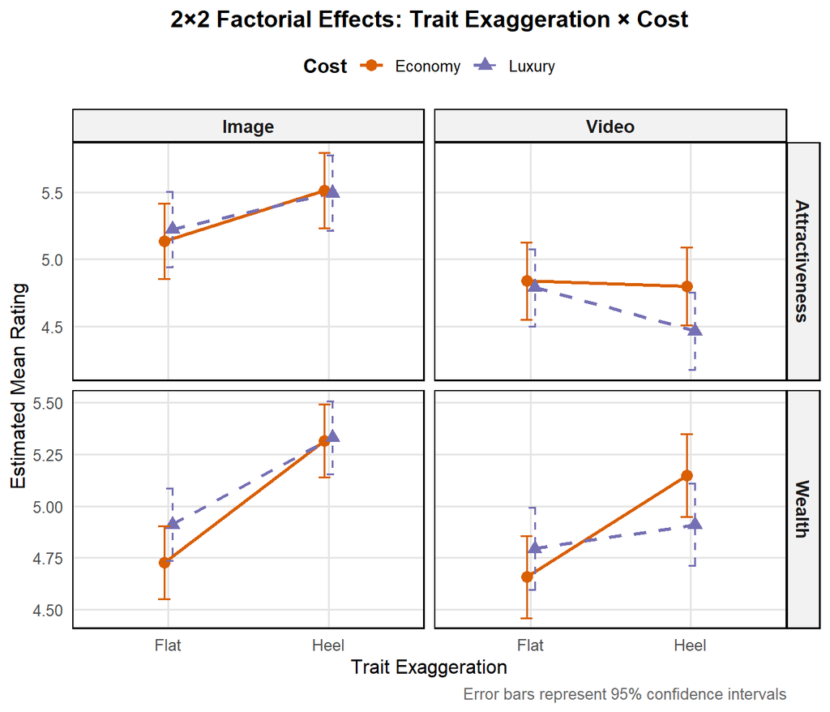

Figure B4.1. Interaction between trait exaggeration (heel vs. flat) and cost (economy vs. luxury) across stimulus types and rating dimensions. Error bars represent 95% confidence intervals.

### 16.2 Main Effects Plots

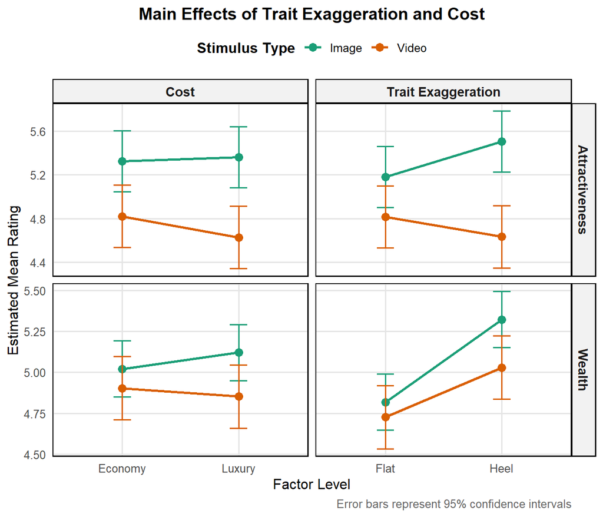

Figure B4.2. Main effects of cost and trait exaggeration across stimulus types for attractiveness and wealth ratings. Error bars represent 95% confidence intervals.

## 17. Effect Size Analysis for 2×2 Factorial Models

### 17.1. Function to Calculate Cohen’s d from emmeans

### 17.2 Calculate Effect Sizes for All Models

```
##
## === ATTRACTIVENESS - IMAGE STIMULI ===
```

```
##
## Main Effect: Trait Exaggeration
```

```
##      contrast   estimate   cohens_d effect_size_label      p.value
## 1 Flat - Heel -0.3250175 -0.2823501             Small 1.984627e-25
```

```
##
## Main Effect: Cost
```

```
##           contrast    estimate    cohens_d effect_size_label   p.value
## 1 Economy - Luxury -0.03631908 -0.03155122        Very Small 0.2442293
```

```
##
## Simple Effects: Trait Exaggeration within Cost levels
```

```
##      contrast   estimate   cohens_d effect_size_label      p.value
## 1 Flat - Heel -0.3791129 -0.3293441             Small 8.314086e-18
## 2 Flat - Heel -0.2709220 -0.2353562             Small 8.128295e-10
```

```
##
##
## === ATTRACTIVENESS - VIDEO STIMULI ===
```

```
##
## Main Effect: Trait Exaggeration
```

```
##      contrast  estimate  cohens_d effect_size_label      p.value
## 1 Flat - Heel 0.1825885 0.1407169        Very Small 2.042923e-07
```

```
##
## Main Effect: Cost
```

```
##           contrast  estimate cohens_d effect_size_label      p.value
## 1 Economy - Luxury 0.1925889 0.148424        Very Small 4.249587e-08
```

```
##
## Simple Effects: Trait Exaggeration within Cost levels
```

```
##      contrast   estimate   cohens_d effect_size_label      p.value
## 1 Flat - Heel 0.04052668 0.03123301        Very Small 4.146398e-01
## 2 Flat - Heel 0.32465027 0.25020076             Small 6.598126e-11
```

```
##
##
## === WEALTH - IMAGE STIMULI ===
```

```
##
## Main Effect: Trait Exaggeration
```

```
##      contrast  estimate   cohens_d effect_size_label      p.value
## 1 Flat - Heel -0.504031 -0.4913652            Medium 2.863108e-73
```

```
##
## Main Effect: Cost
```

```
##           contrast   estimate    cohens_d effect_size_label      p.value
## 1 Economy - Luxury -0.1000797 -0.09756482        Very Small 0.0003243445
```

```
##
## Simple Effects: Trait Exaggeration within Cost levels
```

```
##      contrast   estimate   cohens_d effect_size_label      p.value
## 1 Flat - Heel -0.5885178 -0.5737290            Medium 1.492362e-50
## 2 Flat - Heel -0.4195441 -0.4090014            Medium 1.677902e-26
```

```
##
##
## === WEALTH - VIDEO STIMULI ===
```

```
##
## Main Effect: Trait Exaggeration
```

```
##      contrast   estimate  cohens_d effect_size_label      p.value
## 1 Flat - Heel -0.3026059 -0.247089             Small 7.812207e-20
```

```
##
## Main Effect: Cost
```

```
##           contrast   estimate   cohens_d effect_size_label   p.value
## 1 Economy - Luxury 0.05110851 0.04173199        Very Small 0.1236474
```

```
##
## Simple Effects: Trait Exaggeration within Cost levels
```

```
##      contrast   estimate    cohens_d effect_size_label      p.value
## 1 Flat - Heel -0.4902260 -0.40028769            Medium 1.580942e-25
## 2 Flat - Heel -0.1149859 -0.09389024        Very Small 1.431416e-02
```

### 17.3 Partial Eta-squared from ANOVA Tables

```
##
## === Attractiveness - Image ===
##                          Sum Sq Mean Sq NumDF DenDF  F value  Pr(>F)
## Trait_Exaggeration      143.904 143.904     1  5125 108.6011 0.00000
## Cost                      1.797   1.797     1  5125   1.3560 0.24428
## Trait_Exaggeration:Cost   3.986   3.986     1  5125   3.0083 0.08290
##                         partial_eta_sq effect_size_label
## Trait_Exaggeration           0.0207122                 2
## Cost                         0.0002640                 1
## Trait_Exaggeration:Cost      0.0005855                 1
```

```
##
## === Attractiveness - Video ===
##                         Sum Sq Mean Sq NumDF  DenDF F value     Pr(>F)
## Trait_Exaggeration      45.445  45.445     1 5129.2  26.992 2.1200e-07
## Cost                    50.564  50.564     1 5129.2  30.032 4.5000e-08
## Trait_Exaggeration:Cost 27.514  27.514     1 5129.2  16.342 5.3666e-05
##                         partial_eta_sq effect_size_label
## Trait_Exaggeration           0.0052211                 1
## Cost                         0.0058057                 1
## Trait_Exaggeration:Cost      0.0031675                 1
```

```
##
## === Wealth - Image ===
##                         Sum Sq Mean Sq NumDF  DenDF  F value     Pr(>F)
## Trait_Exaggeration      344.94  344.94     1 5108.1 327.8235 0.00000000
## Cost                     13.60   13.60     1 5108.1  12.9243 0.00032741
## Trait_Exaggeration:Cost   9.69    9.69     1 5108.1   9.2104 0.00241860
##                         partial_eta_sq effect_size_label
## Trait_Exaggeration            0.060127                 3
## Cost                          0.002516                 1
## Trait_Exaggeration:Cost       0.001794                 1
```

```
##
## === Wealth - Video ===
##                          Sum Sq Mean Sq NumDF  DenDF F value  Pr(>F)
## Trait_Exaggeration      124.633 124.633     1 5121.4 83.0971 0.00000
## Cost                      3.555   3.555     1 5121.4  2.3705 0.12371
## Trait_Exaggeration:Cost  47.914  47.914     1 5121.4 31.9460 0.00000
##                         partial_eta_sq effect_size_label
## Trait_Exaggeration           0.0159004                 2
## Cost                         0.0004607                 1
## Trait_Exaggeration:Cost      0.0061732                 1
```

### 17.4 Comprehensive Summary Table of Effect Sizes

```
##                     Model                     Effect Raw_Difference Cohens_d
## 1  Attractiveness - Image  Trait Exaggeration (Main)          0.325     0.28
## 2  Attractiveness - Image                Cost (Main)          0.036     0.03
## 3  Attractiveness - Image Trait × Cost (Interaction)             NA       NA
## 4  Attractiveness - Video  Trait Exaggeration (Main)         -0.183    -0.14
## 5  Attractiveness - Video                Cost (Main)         -0.193    -0.15
## 6  Attractiveness - Video Trait × Cost (Interaction)             NA       NA
## 7          Wealth - Image  Trait Exaggeration (Main)          0.504     0.49
## 8          Wealth - Image                Cost (Main)          0.100     0.10
## 9          Wealth - Image Trait × Cost (Interaction)             NA       NA
## 10         Wealth - Video  Trait Exaggeration (Main)          0.302     0.25
## 11         Wealth - Video                Cost (Main)         -0.051    -0.04
## 12         Wealth - Video Trait × Cost (Interaction)             NA       NA
##    Partial_Eta_Sq
## 1          0.0207
## 2          0.0003
## 3          0.0006
## 4          0.0052
## 5          0.0058
## 6          0.0032
## 7          0.0601
## 8          0.0025
## 9          0.0018
## 10         0.0159
## 11         0.0005
## 12         0.0062
```

### 17.5 Simple Effects Summary for Key Comparisons

[output not shown]

### 17.6 Visualization: Effect Sizes Across Models

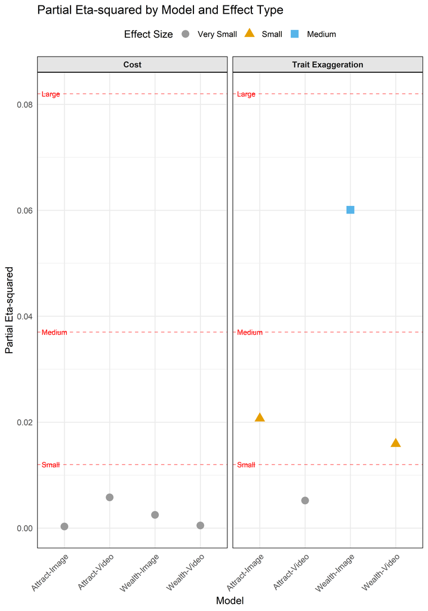

Figure B4.3. Partial Eta-squared effect sizes for main effects across all 2×2 factorial models. Dashed reference lines indicate small (0.012), medium (0.037), and large (0.082) effect size thresholds. For Effect Size Interpretation Guidelines see Supplement Section A3.

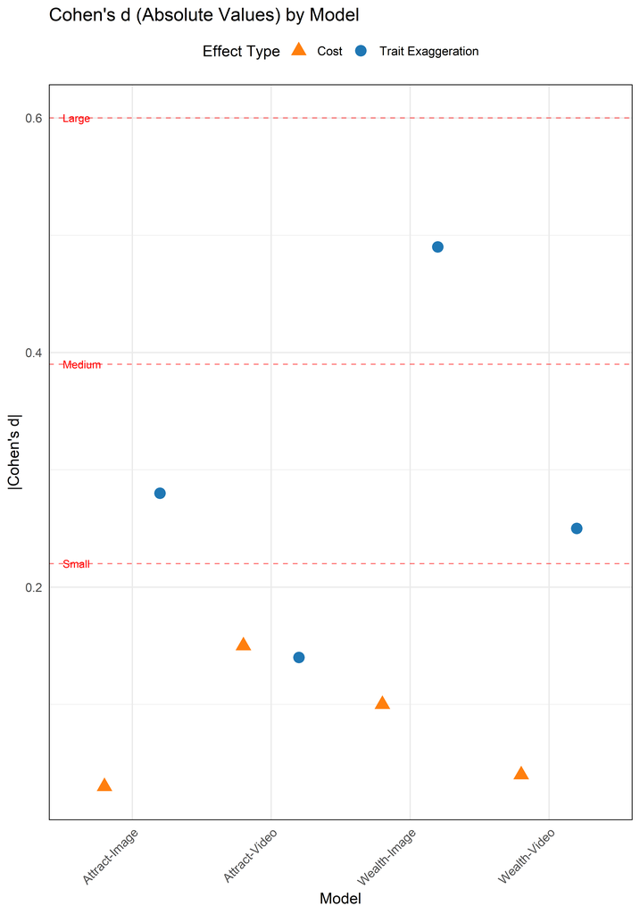

Figure B4.4. Cohen’s d effect sizes (absolute values) for cost and trait exaggeration main effects across all models. Dashed reference lines indicate small (0.22), medium (0.39), and large (0.60) effect size thresholds.For Effect Size Interpretation Guidelines see Supplement Section A3.

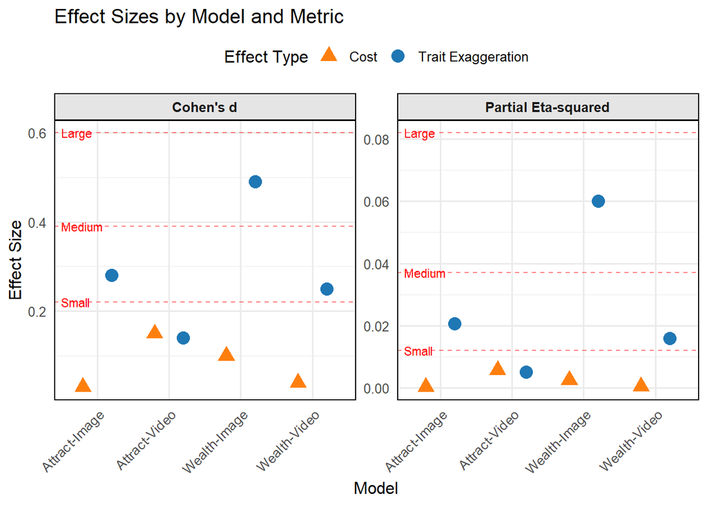

Figure B4.5. Effect sizes for main effects across all 2×2 factorial models, shown as Cohen’s d (left panel) and partial Eta-squared (right panel). Dashed reference lines indicate small, medium, and large effect size thresholds for each metric (d: 0.22, 0.39, 0.60; Eta-squared: 0.012, 0.037, 0.082). For Effect Size Interpretation Guidelines see Supplement Section A3.

## 18. Variance Components Analysis

```
## VARIANCE COMPONENTS ANALYSIS
```

```
## ATTRACTIVENESS MODEL VARIANCE COMPONENTS:
```

```
##       Component  Variance Percentage
## 5      Residual 1.7539217      41.90
## 1          code 1.7190197      41.06
## 2   Model:block 0.6135936      14.66
## 4 Fixed Effects 0.0996007       2.38
## 3         block 0.0000000       0.00
```

```
##
## Percentage of variation explained by:
```

```
## - Individual differences between raters: 41.06 %
```

```
## - Stimuli structure (block/Model nested): 14.66 %
```

```
## - Fixed effects (experimental conditions): 2.38 %
```

```
## - Unexplained variation (residual): 41.9 %
```

```
## WEALTH MODEL VARIANCE COMPONENTS:
```

```
##       Component   Variance Percentage
## 5      Residual 1.40660054      55.45
## 1          code 0.84979078      33.50
## 2   Model:block 0.19431623       7.66
## 4 Fixed Effects 0.08589488       3.39
## 3         block 0.00000000       0.00
```

```
##
## Percentage of variation explained by:
```

```
## - Individual differences between raters: 33.5 %
```

```
## - Stimuli structure (block/Model nested): 7.66 %
```

```
## - Fixed effects (experimental conditions): 3.39 %
```

```
## - Unexplained variation (residual): 55.45 %
```

```
## ATTRACTIVENESS MODEL - IMAGES ONLY:
```

```
##       Component   Variance Percentage
## 1          code 1.98903577      49.37
## 5      Residual 1.33634482      33.17
## 2   Model:block 0.67703476      16.80
## 4 Fixed Effects 0.02673105       0.66
## 3         block 0.00000000       0.00
```

```
##
## ATTRACTIVENESS MODEL - VIDEOS ONLY:
```

```
##       Component   Variance Percentage
## 5      Residual 1.71108107      40.37
## 1          code 1.70473957      40.22
## 2   Model:block 0.78115677      18.43
## 4 Fixed Effects 0.04141337       0.98
## 3         block 0.00000000       0.00
```

```
##
## WEALTH MODEL - IMAGES ONLY:
```

```
##       Component     Variance Percentage
## 5      Residual 1.077144e+00      46.60
## 1          code 9.402658e-01      40.68
## 2   Model:block 1.935133e-01       8.37
## 4 Fixed Effects 1.004498e-01       4.35
## 3         block 1.581079e-09       0.00
```

```
##
## WEALTH MODEL - VIDEOS ONLY:
```

```
##       Component     Variance Percentage
## 5      Residual 1.513379e+00      54.85
## 1          code 8.904654e-01      32.27
## 2   Model:block 2.990295e-01      10.84
## 4 Fixed Effects 5.622153e-02       2.04
## 3         block 2.930203e-08       0.00
```

```
## VARIANCE COMPONENTS SUMMARY ACROSS MODELS
```

```
##             Model Rater_Variance Stimuli_Variance Fixed_Effects Residual
## 1  Attract - Full          41.06            14.66          2.38    41.90
## 2 Attract - Image          49.37            16.80          0.66    33.17
## 3 Attract - Video          40.22            18.43          0.98    40.37
## 4   Wealth - Full          33.50             7.66          3.39    55.45
## 5  Wealth - Image          40.68             8.37          4.35    46.60
## 6  Wealth - Video          32.27            10.84          2.04    54.85
```

## **PART V: Supplement B5: Normality Assumption Checks for Mixed-Effects Models with Nested Structure**

### 20. Function to calculate standardized residuals (Pearson residuals scaled by their standard deviation)

### 21. Function to Check normality of random intercepts for each grouping factor

### 22. Function to perform formal normality tests

### 23. applying the functions to the models from section III

```
## === ATTRACTIVENESS IMAGE MODEL NORMALITY CHECKS ===
```

```
## Note: Shapiro-Wilk performed on random sample of 5000 residuals
## Random effects for block have zero variance (boundary fit) - skipping normality test
```

```
##
## === WEALTH MODEL NORMALITY CHECKS ===
```

```
## Note: Shapiro-Wilk performed on random sample of 5000 residuals
## Random effects for block have zero variance (boundary fit) - skipping normality test
```

### 24. Visualizing the results

```
## Model: Attractiveness, Image
## Residuals Shapiro-Wilk: W = 0.9901 , p = 0
## Residuals Anderson-Darling: A = 11.1158 , p = 0
## Random Effects Tests:
##    code : W = 0.9926 , p = 0.1828
##    Model:block : W = 0.9782 , p = 0.4253
##    block : Test not performed - Zero variance
```

```
## Model: Wealth, Image
## Residuals Shapiro-Wilk: W = 0.9867 , p = 0
## Residuals Anderson-Darling: A = 22.2178 , p = 0
## Random Effects Tests:
##    code : W = 0.9833 , p = 0.0024
##    Model:block : W = 0.9833 , p = 0.6496
##    block : Test not performed - Zero variance
```

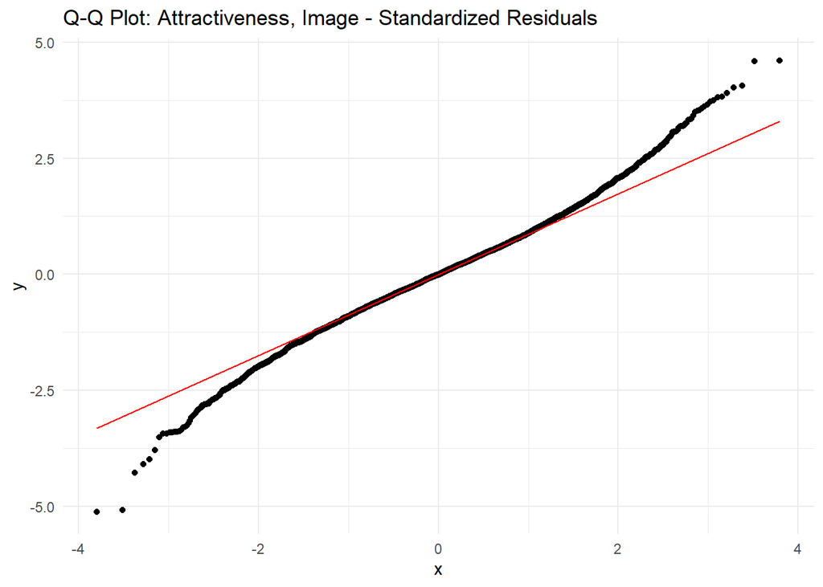

```
## Figure B5.1. Q-Q plot of standardized residuals for attractiveness ratings (image stimuli).
##     Points closely following the reference line (red),
##     indicate approximate normality of residuals.
```

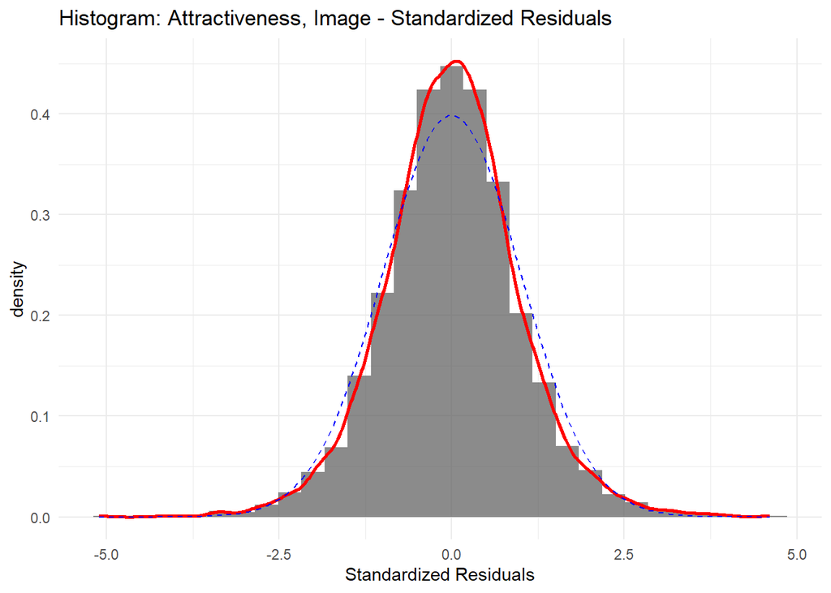

```
## Figure B5.2. Histogram of standardized residuals for attractiveness ratings (image stimuli).
##     Red line shows kernel density estimate;
##     blue dashed line shows theoretical normal distribution (μ=0, σ=1).
```

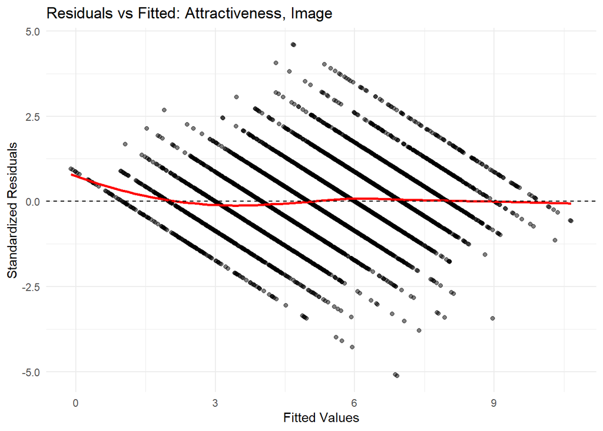

[output not shown]

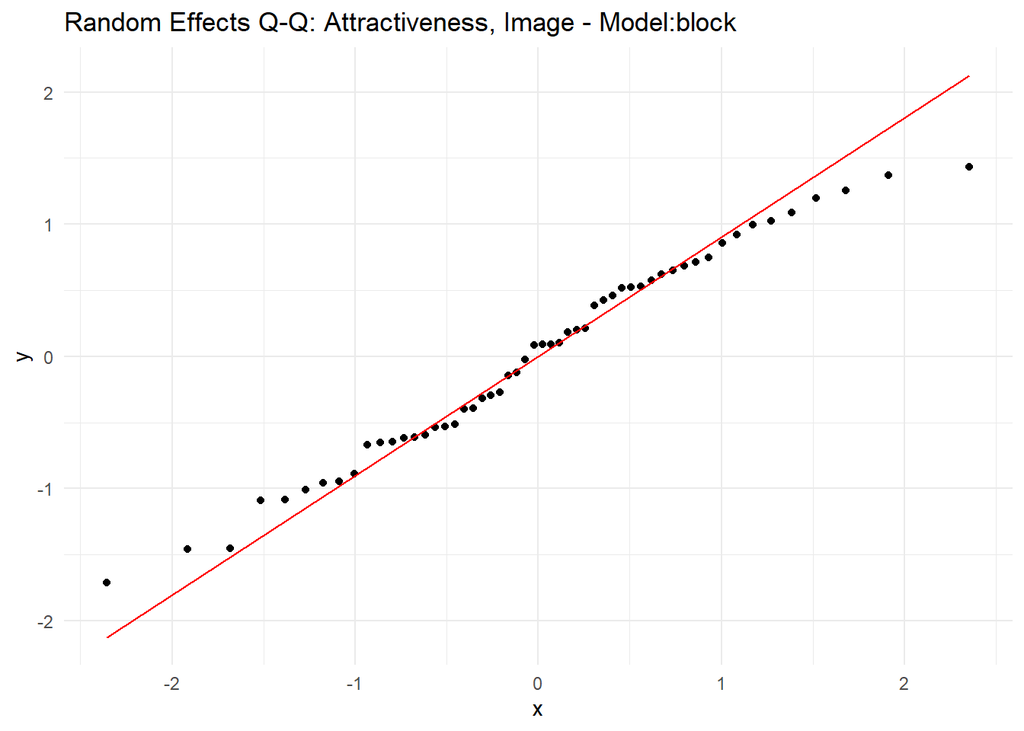

```
## Figure B5.4. Q-Q plot of random intercepts for Model:block grouping factor (attractiveness, image stimuli).
##     Assesses normality assumption for nested random effects structure.
```

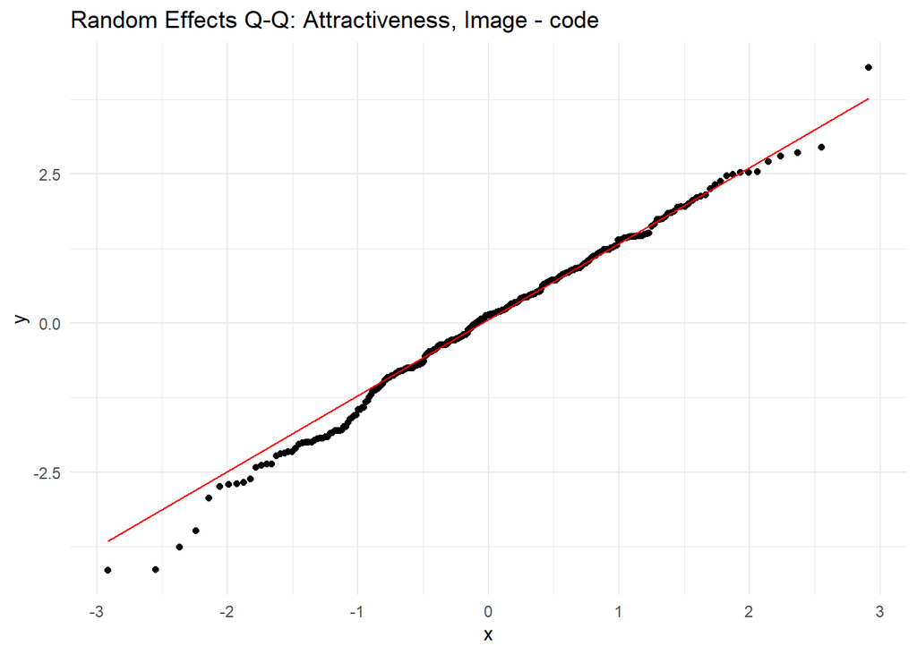

```
## Figure B5.5. Q-Q plot of random intercepts for rater (code) grouping factor (attractiveness, image stimuli).
##     Assesses normality assumption for individual rater effects.
```

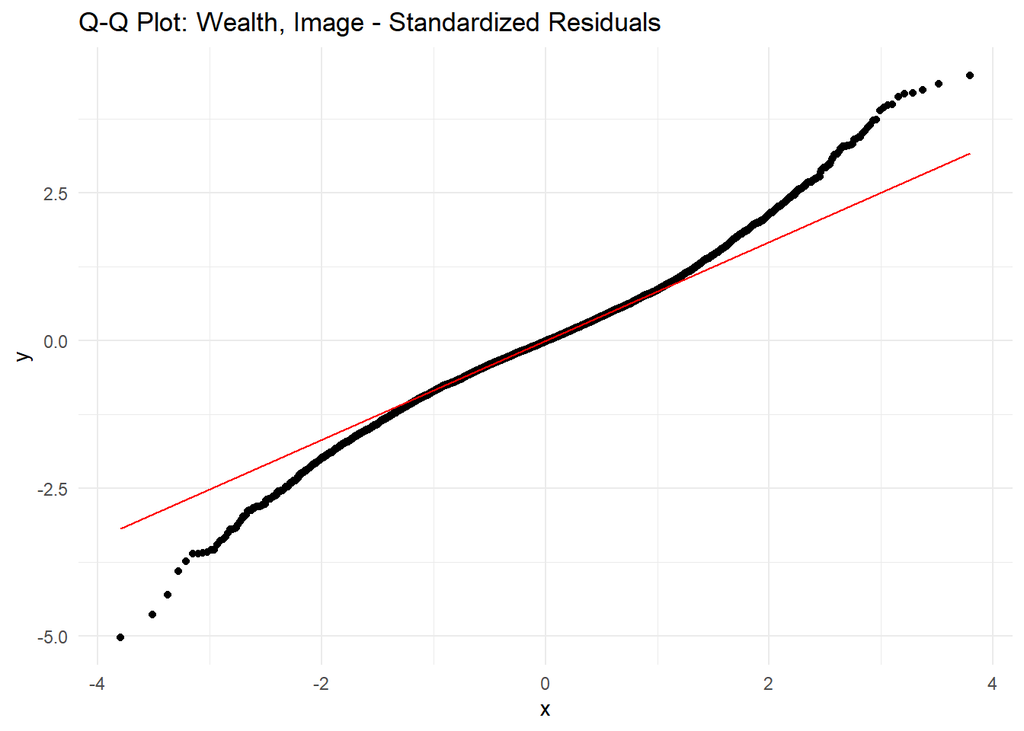

```
## Figure B5.6. Q-Q plot of standardized residuals for wealth perception ratings (image stimuli).
##     Points closely following the reference line (red),
##     indicate approximate normality of residuals.
```

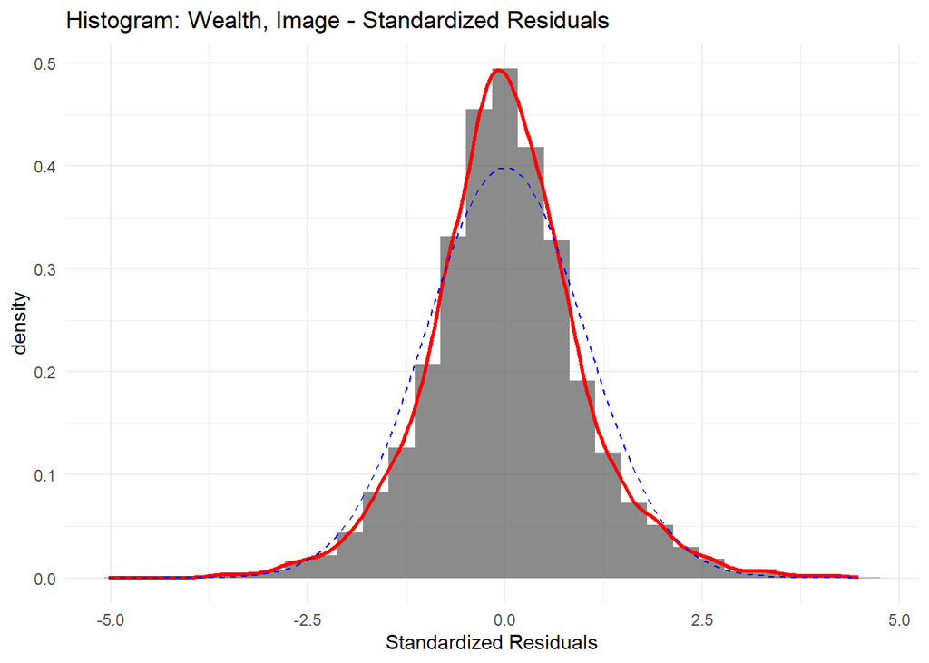

```
## Figure B5.7. Histogram of standardized residuals for wealth perception ratings (image stimuli).
##     Red line shows kernel density estimate;
##     blue dashed line shows theoretical normal distribution (μ=0, σ=1).
```

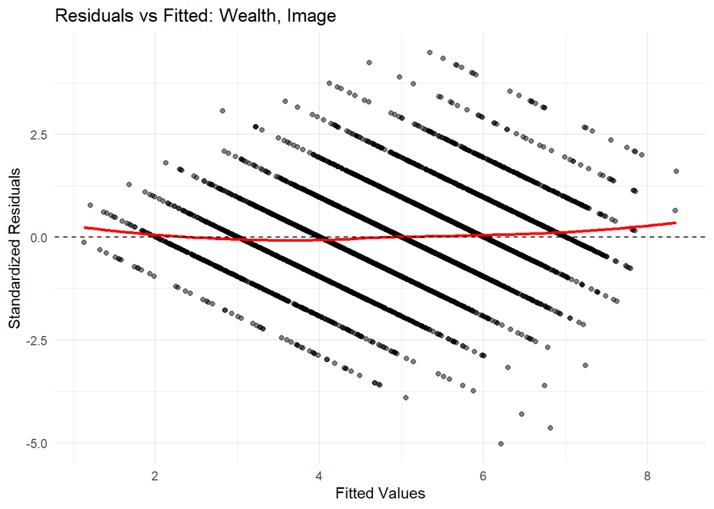

```
## Figure B5.8. Standardized residuals versus fitted values for wealth perception ratings (image stimuli).
##     Red loess curve and horizontal reference line assess homoscedasticity assumption.
```

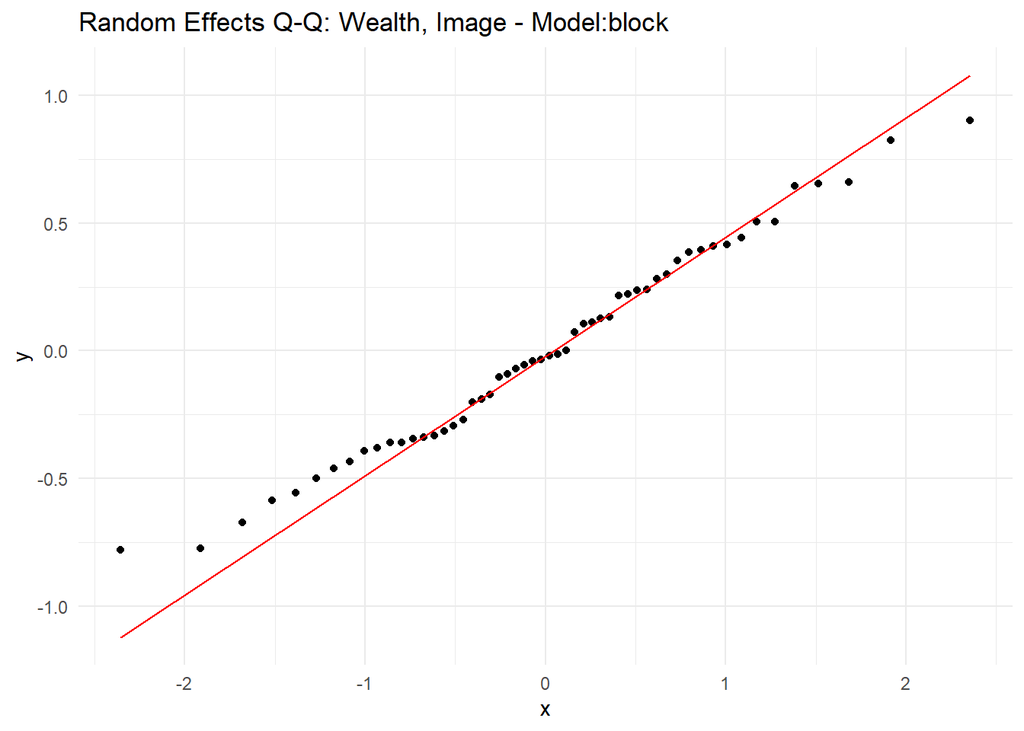

```
## Figure B5.9. Q-Q plot of random intercepts for Model:block grouping factor (wealth, image stimuli).
##     Assesses normality assumption for nested random effects structure.
```

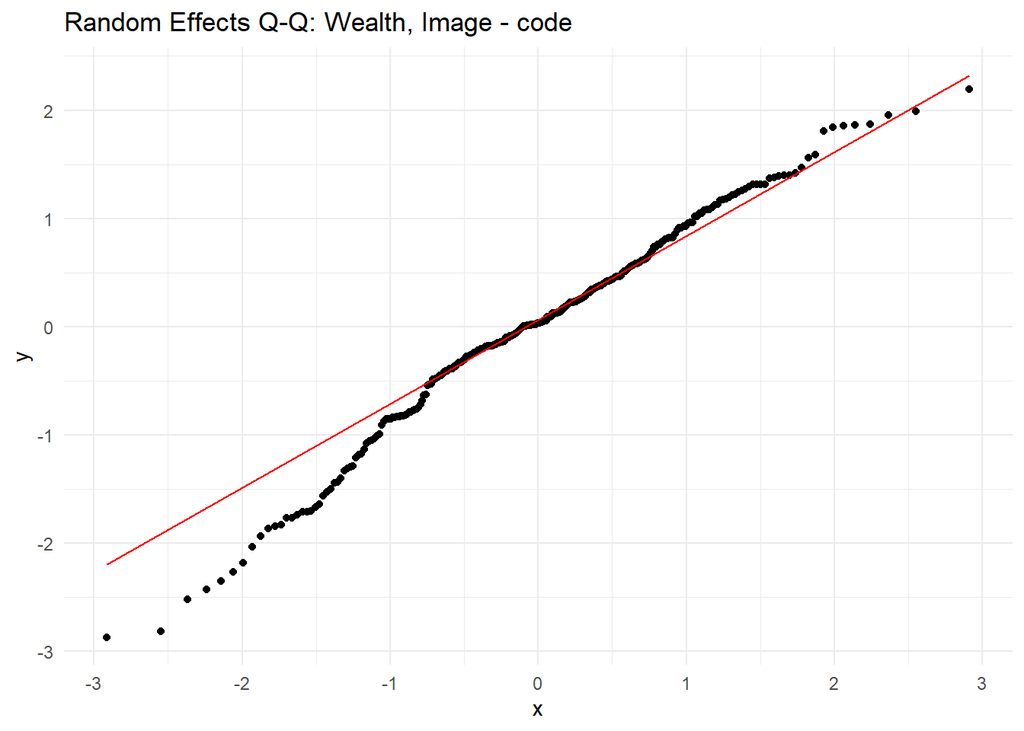

```
## Figure B5.10. Q-Q plot of random intercepts for rater (code) grouping factor (wealth, image stimuli).
##     Assesses normality assumption for individual rater effects.
```

### 25. Diagnostic for Boundary fits and random effects variance

```
## === RANDOM EFFECTS EXAMINATION: Attractiveness ===
## WARNING: Model has singular/boundary fit - some variance components are zero
## Variance Components:
##  Groups      Name        Std.Dev.
##  code        (Intercept) 1.41033
##  Model:block (Intercept) 0.82282
##  block       (Intercept) 0.00000
##  Residual                1.15600
##
## Random Effects for code :
##   Number of levels: 279
##   Range: -4.1435 4.2883
##   Mean: 0
##   SD: 1.3754
##   Variance: 1.891649
##   Quick normality assessment:
##     Skewness: -0.24
##     Kurtosis: 3.116
##
## Random Effects for Model:block :
##   Number of levels: 54
##   Range: -1.7143 1.4323
##   Mean: 0
##   SD: 0.7882
##   Variance: 0.621337
##   Quick normality assessment:
##     Skewness: -0.114
##     Kurtosis: 2.168
##
## Random Effects for block :
##   Number of levels: 11
##   Range: 0 0
##   Mean: 0
##   SD: 0
##   Variance: 0
##   ** Near-zero variance detected (boundary fit)
```

```
## === RANDOM EFFECTS EXAMINATION: Wealth ===
## WARNING: Model has singular/boundary fit - some variance components are zero
## Variance Components:
##  Groups      Name        Std.Dev.
##  code        (Intercept) 9.6967e-01
##  Model:block (Intercept) 4.3990e-01
##  block       (Intercept) 3.9763e-05
##  Residual                1.0379e+00
##
## Random Effects for code :
##   Number of levels: 279
##   Range: -2.8667 2.1965
##   Mean: 0
##   SD: 0.9389
##   Variance: 0.881581
##   Quick normality assessment:
##     Skewness: -0.427
##     Kurtosis: 3.241
##
## Random Effects for Model:block :
##   Number of levels: 54
##   Range: -0.7785 0.9024
##   Mean: 0
##   SD: 0.4107
##   Variance: 0.168686
##   Quick normality assessment:
##     Skewness: 0.149
##     Kurtosis: 2.305
##
## Random Effects for block :
##   Number of levels: 11
##   Range: 0 0
##   Mean: 0
##   SD: 0
##   Variance: 0
##   ** Near-zero variance detected (boundary fit)
```

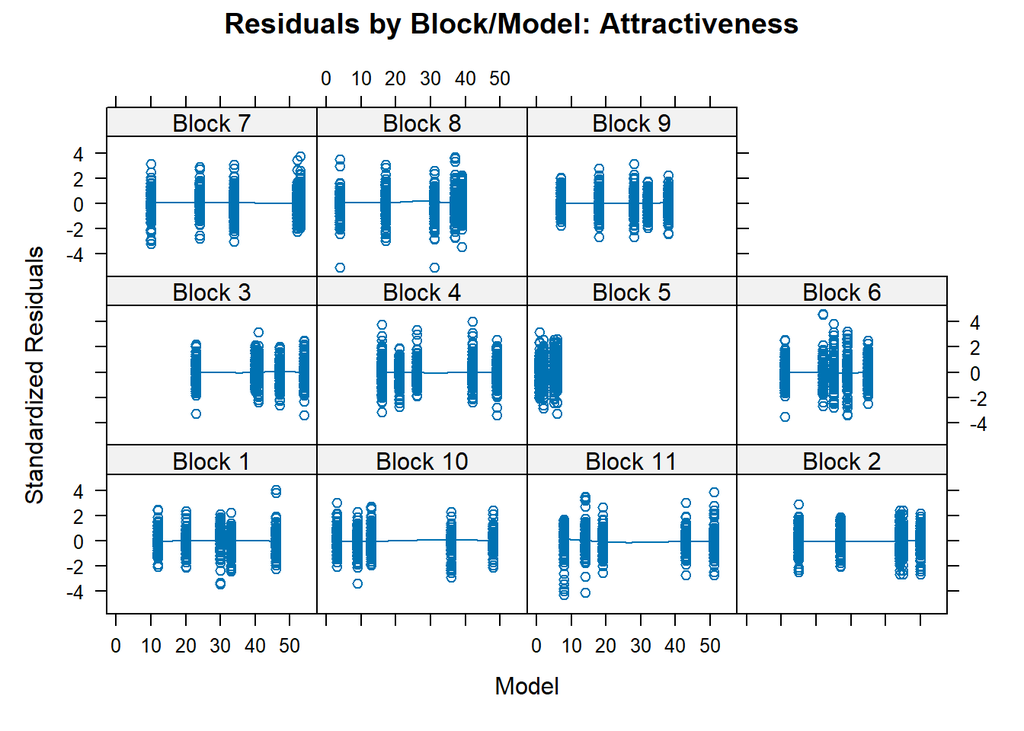

```
## Figure B5.11. Standardized residuals by nested structure (Block/Model) for attractiveness ratings.
##     Panel plot shows residual patterns across experimental blocks
##     with loess smoothing curves to detect systematic variation.
```

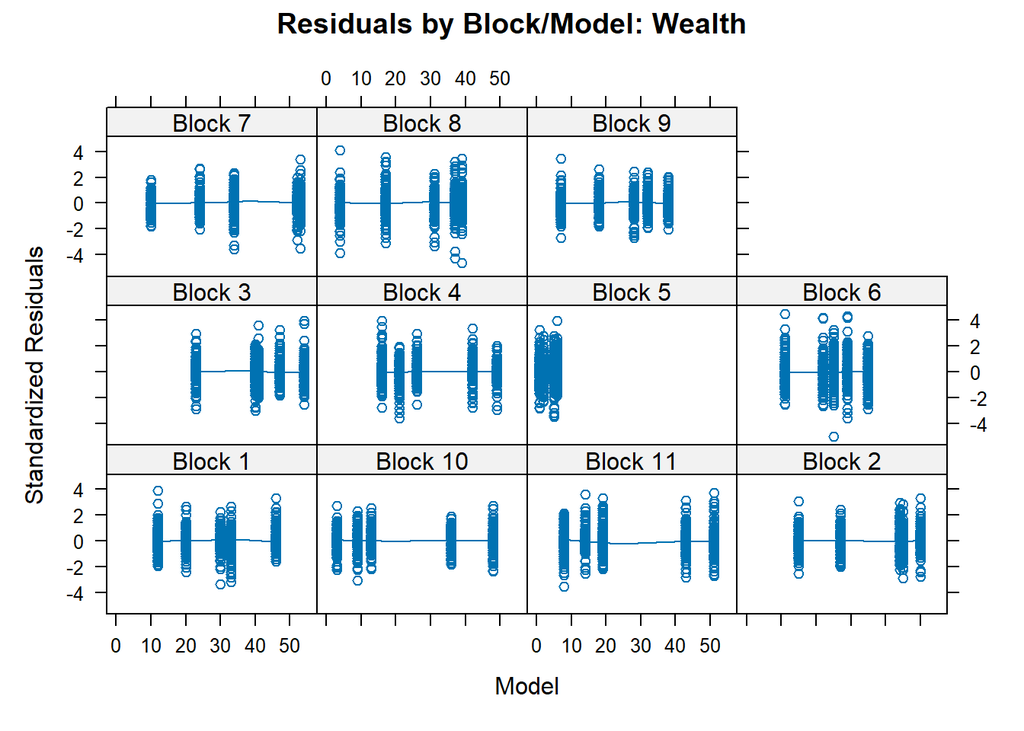

```
## Figure B5.12. Standardized residuals by nested structure (Block/Model) for wealth perception ratings.
##     Panel plot shows residual patterns across experimental blocks
##     with loess smoothing curves to detect systematic variation.
```

## **PART VI: Supplement section B6: Power Analysis**

### Stimulus-Level Power Sensitivity Analysis

[output not shown]

[output not shown]

[output not shown]

[output not shown]

[output not shown]

[output not shown]

[output not shown]

[output not shown]

[output not shown]

[output not shown]

[output not shown]

[output not shown]

[output not shown]

[output not shown]

[output not shown]

[output not shown]

[output not shown]

[output not shown]

[output not shown]

[output not shown]

[output not shown]

[output not shown]

[output not shown]

[output not shown]

[output not shown]

[output not shown]

[output not shown]

[output not shown]

[output not shown]

[output not shown]

[output not shown]

[output not shown]

[output not shown]

[output not shown]

[output not shown]

[output not shown]

[output not shown]

[output not shown]

[output not shown]

[output not shown]

[output not shown]

[output not shown]

[output not shown]

[output not shown]

[output not shown]

[output not shown]

[output not shown]

[output not shown]

[output not shown]

[output not shown]

[output not shown]

[output not shown]

[output not shown]

[output not shown]

[output not shown]

[output not shown]

[output not shown]

[output not shown]

[output not shown]

[output not shown]

[output not shown]

[output not shown]

[output not shown]

[output not shown]

[output not shown]

[output not shown]

[output not shown]

[output not shown]

[output not shown]

[output not shown]

[output not shown]

[output not shown]

[output not shown]

[output not shown]

[output not shown]

[output not shown]

[output not shown]

[output not shown]

[output not shown]

[output not shown]

[output not shown]

[output not shown]

[output not shown]

[output not shown]

[output not shown]

[output not shown]

[output not shown]

[output not shown]

[output not shown]

[output not shown]

[output not shown]

[output not shown]

[output not shown]

[output not shown]

[output not shown]

[output not shown]

[output not shown]

[output not shown]

[output not shown]

[output not shown]

[output not shown]

[output not shown]

[output not shown]

[output not shown]

[output not shown]

[output not shown]

[output not shown]

[output not shown]

[output not shown]

[output not shown]

[output not shown]

[output not shown]

[output not shown]

[output not shown]

[output not shown]

[output not shown]

[output not shown]

[output not shown]

[output not shown]

[output not shown]

[output not shown]

[output not shown]

[output not shown]

[output not shown]

[output not shown]

[output not shown]

[output not shown]

[output not shown]

[output not shown]

[output not shown]

[output not shown]

[output not shown]

[output not shown]

[output not shown]

[output not shown]

[output not shown]

[output not shown]

[output not shown]

[output not shown]

[output not shown]

[output not shown]

[output not shown]

[output not shown]

[output not shown]

[output not shown]

[output not shown]

[output not shown]

[output not shown]

[output not shown]

[output not shown]

[output not shown]

[output not shown]

[output not shown]

[output not shown]

[output not shown]

[output not shown]

[output not shown]

[output not shown]

[output not shown]

[output not shown]

[output not shown]

[output not shown]

[output not shown]

[output not shown]

[output not shown]

[output not shown]

[output not shown]

[output not shown]

[output not shown]

[output not shown]

[output not shown]

[output not shown]

[output not shown]

[output not shown]

[output not shown]

[output not shown]

[output not shown]

[output not shown]

[output not shown]

[output not shown]

[output not shown]

[output not shown]

[output not shown]

[output not shown]

[output not shown]

[output not shown]

[output not shown]

[output not shown]

[output not shown]

[output not shown]

[output not shown]

[output not shown]

[output not shown]

[output not shown]

[output not shown]

[output not shown]

[output not shown]

[output not shown]

[output not shown]

[output not shown]

[output not shown]

[output not shown]

[output not shown]

[output not shown]

[output not shown]

[output not shown]

[output not shown]

[output not shown]

[output not shown]

[output not shown]

[output not shown]

[output not shown]

[output not shown]

[output not shown]

[output not shown]

[output not shown]

[output not shown]

[output not shown]

[output not shown]

[output not shown]

[output not shown]

[output not shown]

[output not shown]

[output not shown]

[output not shown]

[output not shown]

[output not shown]

[output not shown]

[output not shown]

[output not shown]

[output not shown]

[output not shown]

[output not shown]

[output not shown]

[output not shown]

[output not shown]

[output not shown]

[output not shown]

[output not shown]

[output not shown]

[output not shown]

[output not shown]

[output not shown]

[output not shown]

[output not shown]

[output not shown]

[output not shown]

[output not shown]

[output not shown]

[output not shown]

[output not shown]

[output not shown]

[output not shown]

[output not shown]

[output not shown]

[output not shown]

[output not shown]

[output not shown]

[output not shown]

[output not shown]

[output not shown]

[output not shown]

[output not shown]

[output not shown]

[output not shown]

[output not shown]

[output not shown]

[output not shown]

[output not shown]

[output not shown]

[output not shown]

[output not shown]

[output not shown]

[output not shown]

[output not shown]

[output not shown]

[output not shown]

[output not shown]

[output not shown]

[output not shown]

[output not shown]

[output not shown]

[output not shown]

[output not shown]

[output not shown]

[output not shown]

[output not shown]

[output not shown]

[output not shown]

[output not shown]

[output not shown]

[output not shown]

[output not shown]

[output not shown]

[output not shown]

[output not shown]

[output not shown]

[output not shown]

[output not shown]

[output not shown]

[output not shown]

```
## Power for predictor 'Condition', (95% confidence interval),
## by number of levels in Model:
##      20:  0.00% ( 0.00,  0.37) - 1993 rows
##      30:  0.00% ( 0.00,  0.37) - 3036 rows
##      40:  0.00% ( 0.00,  0.37) - 4048 rows
##      50:  0.00% ( 0.00,  0.37) - 5046 rows
##      NA:  0.00% ( 0.00,  0.37) - 5450 rows
##
## Time elapsed: 0 h 15 m 18 s
```

[output not shown]

[output not shown]

[output not shown]

[output not shown]

[output not shown]

[output not shown]

[output not shown]

[output not shown]

[output not shown]

[output not shown]

[output not shown]

[output not shown]

[output not shown]

[output not shown]

[output not shown]

[output not shown]

[output not shown]

[output not shown]

[output not shown]

[output not shown]

[output not shown]

[output not shown]

[output not shown]

[output not shown]

[output not shown]

[output not shown]

[output not shown]

[output not shown]

[output not shown]

[output not shown]

[output not shown]

[output not shown]

[output not shown]

[output not shown]

[output not shown]

[output not shown]

[output not shown]

[output not shown]

[output not shown]

[output not shown]

[output not shown]

[output not shown]

[output not shown]

[output not shown]

[output not shown]

[output not shown]

[output not shown]

[output not shown]

[output not shown]

[output not shown]

[output not shown]

[output not shown]

[output not shown]

[output not shown]

[output not shown]

[output not shown]

[output not shown]

[output not shown]

[output not shown]

[output not shown]

[output not shown]

[output not shown]

[output not shown]

[output not shown]

[output not shown]

[output not shown]

[output not shown]

[output not shown]

[output not shown]

[output not shown]

[output not shown]

[output not shown]

[output not shown]

[output not shown]

[output not shown]

[output not shown]

[output not shown]

[output not shown]

[output not shown]

[output not shown]

[output not shown]

[output not shown]

[output not shown]

[output not shown]

[output not shown]

[output not shown]

[output not shown]

[output not shown]

[output not shown]

[output not shown]

[output not shown]

[output not shown]

[output not shown]

[output not shown]

[output not shown]

[output not shown]

[output not shown]

[output not shown]

[output not shown]

[output not shown]

[output not shown]

[output not shown]

[output not shown]

[output not shown]

[output not shown]

[output not shown]

[output not shown]

[output not shown]

[output not shown]

[output not shown]

[output not shown]

[output not shown]

[output not shown]

[output not shown]

[output not shown]

[output not shown]

[output not shown]

[output not shown]

[output not shown]

[output not shown]

[output not shown]

[output not shown]

[output not shown]

[output not shown]

[output not shown]

[output not shown]

[output not shown]

[output not shown]

[output not shown]

[output not shown]

[output not shown]

[output not shown]

[output not shown]

[output not shown]

[output not shown]

[output not shown]

[output not shown]

[output not shown]

[output not shown]

[output not shown]

[output not shown]

[output not shown]

[output not shown]

[output not shown]

[output not shown]

[output not shown]

[output not shown]

[output not shown]

[output not shown]

[output not shown]

[output not shown]

[output not shown]

[output not shown]

[output not shown]

[output not shown]

[output not shown]

[output not shown]

[output not shown]

[output not shown]

[output not shown]

[output not shown]

[output not shown]

[output not shown]

[output not shown]

[output not shown]

[output not shown]

[output not shown]

[output not shown]

[output not shown]

[output not shown]

[output not shown]

[output not shown]

[output not shown]

[output not shown]

[output not shown]

[output not shown]

[output not shown]

[output not shown]

[output not shown]

[output not shown]

[output not shown]

[output not shown]

[output not shown]

[output not shown]

[output not shown]

[output not shown]

[output not shown]

[output not shown]

[output not shown]

[output not shown]

[output not shown]

[output not shown]

[output not shown]

[output not shown]

[output not shown]

[output not shown]

[output not shown]

[output not shown]

[output not shown]

[output not shown]

[output not shown]

[output not shown]

[output not shown]

[output not shown]

[output not shown]

[output not shown]

[output not shown]

[output not shown]

[output not shown]

[output not shown]

[output not shown]

[output not shown]

[output not shown]

[output not shown]

[output not shown]

[output not shown]

[output not shown]

[output not shown]

[output not shown]

[output not shown]

[output not shown]

[output not shown]

[output not shown]

[output not shown]

[output not shown]

[output not shown]

[output not shown]

[output not shown]

[output not shown]

[output not shown]

[output not shown]

[output not shown]

[output not shown]

[output not shown]

[output not shown]

[output not shown]

[output not shown]

[output not shown]

[output not shown]

[output not shown]

[output not shown]

[output not shown]

[output not shown]

[output not shown]

[output not shown]

[output not shown]

[output not shown]

[output not shown]

[output not shown]

[output not shown]

[output not shown]

[output not shown]

[output not shown]

[output not shown]

[output not shown]

[output not shown]

[output not shown]

[output not shown]

[output not shown]

[output not shown]

[output not shown]

[output not shown]

[output not shown]

[output not shown]

[output not shown]

[output not shown]

[output not shown]

[output not shown]

[output not shown]

[output not shown]

[output not shown]

[output not shown]

[output not shown]

[output not shown]

[output not shown]

[output not shown]

[output not shown]

[output not shown]

[output not shown]

[output not shown]

[output not shown]

[output not shown]

[output not shown]

[output not shown]

[output not shown]

[output not shown]

[output not shown]

[output not shown]

[output not shown]

[output not shown]

[output not shown]

[output not shown]

[output not shown]

[output not shown]

[output not shown]

[output not shown]

[output not shown]

[output not shown]

[output not shown]

[output not shown]

[output not shown]

```
## Power for predictor 'Condition', (95% confidence interval),
## by number of levels in Model:
##      20:  0.00% ( 0.00,  0.37) - 1987 rows
##      30:  0.00% ( 0.00,  0.37) - 3025 rows
##      40:  0.00% ( 0.00,  0.37) - 4035 rows
##      50:  0.00% ( 0.00,  0.37) - 5029 rows
##      NA:  0.00% ( 0.00,  0.37) - 5433 rows
##
## Time elapsed: 0 h 14 m 28 s
```

### Rater level sample power analysis

```
## 2x2 Factorial Design: Trait_Exaggeration × Cost
```

```
##
## ======================================================================
## MODEL: ATTRACTIVENESS - IMAGE STIMULI
## ======================================================================
```

```
##
## ======================================================================
## MODEL: WEALTH - IMAGE STIMULI
## ======================================================================
```

```
## STEP 2: ACHIEVED POWER ANALYSIS
```

```
## (Power achieved with observed effect sizes)
```

```
##
## Calculating achieved power for: ATTRACTIVENESS - IMAGE
## Number of simulations: 1000
## This may take a few minutes...
##
## Analyzing: Main effect of Trait_Exaggeration...
## Simulating: |                                                                  |
```

[output not shown]

[output not shown]

[output not shown]

[output not shown]

[output not shown]

[output not shown]

[output not shown]

[output not shown]

[output not shown]

[output not shown]

[output not shown]

[output not shown]

[output not shown]

[output not shown]

[output not shown]

[output not shown]

[output not shown]

[output not shown]

[output not shown]

[output not shown]

[output not shown]

[output not shown]

[output not shown]

[output not shown]

[output not shown]

[output not shown]

[output not shown]

[output not shown]

[output not shown]

[output not shown]

[output not shown]

[output not shown]

[output not shown]

[output not shown]

[output not shown]

[output not shown]

[output not shown]

[output not shown]

[output not shown]

[output not shown]

[output not shown]

[output not shown]

[output not shown]

[output not shown]

[output not shown]

[output not shown]

[output not shown]

[output not shown]

[output not shown]

[output not shown]

[output not shown]

[output not shown]

[output not shown]

[output not shown]

[output not shown]

[output not shown]

[output not shown]

[output not shown]

[output not shown]

[output not shown]

[output not shown]

[output not shown]

[output not shown]

[output not shown]

[output not shown]

[output not shown]

```
##
## Trait_Exaggeration Power Results:
## Power for predictor 'Trait_Exaggeration1', (95% confidence interval):
##       100.0% (99.63, 100.0)
##
## Test: z-test
##       Effect size for Trait_Exaggeration1 is -0.16
##
## Based on 1000 simulations, (56 warnings, 0 errors)
## alpha = 0.05, nrow = 5450
##
## Time elapsed: 0 h 5 m 16 s
##
## nb: result might be an observed power calculation
##
##
## Analyzing: Main effect of Cost...
## Simulating: |                                                                  |
```

[output not shown]

[output not shown]

[output not shown]

[output not shown]

[output not shown]

[output not shown]

[output not shown]

[output not shown]

[output not shown]

[output not shown]

[output not shown]

[output not shown]

[output not shown]

[output not shown]

[output not shown]

[output not shown]

[output not shown]

[output not shown]

[output not shown]

[output not shown]

[output not shown]

[output not shown]

[output not shown]

[output not shown]

[output not shown]

[output not shown]

[output not shown]

[output not shown]

[output not shown]

[output not shown]

[output not shown]

[output not shown]

[output not shown]

[output not shown]

[output not shown]

[output not shown]

[output not shown]

[output not shown]

[output not shown]

[output not shown]

[output not shown]

[output not shown]

[output not shown]

[output not shown]

[output not shown]

[output not shown]

[output not shown]

[output not shown]

[output not shown]

[output not shown]

[output not shown]

[output not shown]

[output not shown]

[output not shown]

[output not shown]

[output not shown]

[output not shown]

[output not shown]

[output not shown]

[output not shown]

[output not shown]

[output not shown]

[output not shown]

[output not shown]

[output not shown]

[output not shown]

```
##
## Cost Power Results:
## Power for predictor 'Cost1', (95% confidence interval):
##       21.80% (19.28, 24.49)
##
## Test: z-test
##       Effect size for Cost1 is -0.018
##
## Based on 1000 simulations, (54 warnings, 0 errors)
## alpha = 0.05, nrow = 5450
##
## Time elapsed: 0 h 5 m 11 s
##
## nb: result might be an observed power calculation
```

```
##
## Calculating achieved power for: WEALTH - IMAGE
## Number of simulations: 1000
## This may take a few minutes...
##
## Analyzing: Main effect of Trait_Exaggeration...
## Simulating: |                                                                  |
```

[output not shown]

[output not shown]

[output not shown]

[output not shown]

[output not shown]

[output not shown]

[output not shown]

[output not shown]

[output not shown]

[output not shown]

[output not shown]

[output not shown]

[output not shown]

[output not shown]

[output not shown]

[output not shown]

[output not shown]

[output not shown]

[output not shown]

[output not shown]

[output not shown]

[output not shown]

[output not shown]

[output not shown]

[output not shown]

[output not shown]

[output not shown]

[output not shown]

[output not shown]

[output not shown]

[output not shown]

[output not shown]

[output not shown]

[output not shown]

[output not shown]

[output not shown]

[output not shown]

[output not shown]

[output not shown]

[output not shown]

[output not shown]

[output not shown]

[output not shown]

[output not shown]

[output not shown]

[output not shown]

[output not shown]

[output not shown]

[output not shown]

[output not shown]

[output not shown]

[output not shown]

[output not shown]

[output not shown]

[output not shown]

[output not shown]

[output not shown]

[output not shown]

[output not shown]

[output not shown]

[output not shown]

[output not shown]

[output not shown]

[output not shown]

[output not shown]

[output not shown]

```
##
## Trait_Exaggeration Power Results:
## Power for predictor 'Trait_Exaggeration1', (95% confidence interval):
##       100.0% (99.63, 100.0)
##
## Test: z-test
##       Effect size for Trait_Exaggeration1 is -0.25
##
## Based on 1000 simulations, (38 warnings, 0 errors)
## alpha = 0.05, nrow = 5433
##
## Time elapsed: 0 h 5 m 13 s
##
## nb: result might be an observed power calculation
##
##
## Analyzing: Main effect of Cost...
## Simulating: |                                                                  |
```

[output not shown]

[output not shown]

[output not shown]

[output not shown]

[output not shown]

[output not shown]

[output not shown]

[output not shown]

[output not shown]

[output not shown]

[output not shown]

[output not shown]

[output not shown]

[output not shown]

[output not shown]

[output not shown]

[output not shown]

[output not shown]

[output not shown]

[output not shown]

[output not shown]

[output not shown]

[output not shown]

[output not shown]

[output not shown]

[output not shown]

[output not shown]

[output not shown]

[output not shown]

[output not shown]

[output not shown]

[output not shown]

[output not shown]

[output not shown]

[output not shown]

[output not shown]

[output not shown]

[output not shown]

[output not shown]

[output not shown]

[output not shown]

[output not shown]

[output not shown]

[output not shown]

[output not shown]

[output not shown]

[output not shown]

[output not shown]

[output not shown]

[output not shown]

[output not shown]

[output not shown]

[output not shown]

[output not shown]

[output not shown]

[output not shown]

[output not shown]

[output not shown]

[output not shown]

[output not shown]

[output not shown]

[output not shown]

[output not shown]

[output not shown]

[output not shown]

[output not shown]

```
##
## Cost Power Results:
## Power for predictor 'Cost1', (95% confidence interval):
##       94.60% (93.01, 95.92)
##
## Test: z-test
##       Effect size for Cost1 is -0.050
##
## Based on 1000 simulations, (31 warnings, 0 errors)
## alpha = 0.05, nrow = 5433
##
## Time elapsed: 0 h 5 m 1 s
##
## nb: result might be an observed power calculation
```

```
## STEP 3: MINIMUM DETECTABLE EFFECT SIZE ANALYSIS
```

```
## (Smallest effect detectable with 80% power)
```

```
## ATTRACTIVENESS MODEL - MDES Analysis
```

```
##
## Finding MDES for: Trait_Exaggeration1 in ATTRACTIVENESS - Trait_Exaggeration
## Target power: 0.8
## This will test multiple effect sizes...
##
## Observed effect size: -0.1625
## Testing effect size:-0.0325(20% of observed)...
```

```
##   Power:0.52 [0.448, 0.591]
## Testing effect size:-0.065(40% of observed)...
```

```
##   Power:0.985 [0.957, 0.997]
## Testing effect size:-0.0975(60% of observed)...
```

```
##   Power:1 [0.982, 1]
## Testing effect size:-0.13(80% of observed)...
```

```
##   Power:1 [0.982, 1]
## Testing effect size:-0.1625(100% of observed)...
```

```
##   Power:1 [0.982, 1]
## Testing effect size:-0.195(120% of observed)...
```

```
##   Power:1 [0.982, 1]
## Testing effect size:-0.2275(140% of observed)...
```

```
##   Power:1 [0.982, 1]
## Testing effect size:-0.26(160% of observed)...
```

```
##   Power:1 [0.982, 1]
## Testing effect size:-0.2925(180% of observed)...
```

```
##   Power:1 [0.982, 1]
## Testing effect size:-0.325(200% of observed)...
```

```
##   Power:1 [0.982, 1]
##
## ** MINIMUM DETECTABLE EFFECT SIZE **
## Effect size for ~80% power: -0.065
## Achieved power at this effect size: 0.985
## This is 40% of the observed effect
```

```
##
## Finding MDES for: Cost1 in ATTRACTIVENESS - Cost
## Target power: 0.8
## This will test multiple effect sizes...
##
## Observed effect size: -0.0182
## Testing effect size:-0.0036(20% of observed)...
```

```
##   Power:0.045 [0.021, 0.084]
## Testing effect size:-0.0073(40% of observed)...
```

```
##   Power:0.085 [0.05, 0.133]
## Testing effect size:-0.0109(60% of observed)...
```

```
##   Power:0.105 [0.066, 0.156]
## Testing effect size:-0.0145(80% of observed)...
```

```
##   Power:0.17 [0.121, 0.229]
## Testing effect size:-0.0182(100% of observed)...
```

```
##   Power:0.215 [0.16, 0.278]
## Testing effect size:-0.0218(120% of observed)...
```

```
##   Power:0.25 [0.192, 0.316]
## Testing effect size:-0.0254(140% of observed)...
```

```
##   Power:0.325 [0.261, 0.395]
## Testing effect size:-0.0291(160% of observed)...
```

```
##   Power:0.405 [0.336, 0.477]
## Testing effect size:-0.0327(180% of observed)...
```

```
##   Power:0.535 [0.463, 0.606]
## Testing effect size:-0.0363(200% of observed)...
```

```
##   Power:0.61 [0.539, 0.678]
##
## ** MINIMUM DETECTABLE EFFECT SIZE **
## Effect size for ~80% power: -0.0363
## Achieved power at this effect size: 0.61
## This is 200% of the observed effect
```

```
## WEALTH MODEL - MDES Analysis
```

```
##
## Finding MDES for: Trait_Exaggeration1 in WEALTH - Trait_Exaggeration
## Target power: 0.8
## This will test multiple effect sizes...
##
## Observed effect size: -0.252
## Testing effect size:-0.0504(20% of observed)...
```

```
##   Power:0.965 [0.929, 0.986]
## Testing effect size:-0.1008(40% of observed)...
```

```
##   Power:1 [0.982, 1]
## Testing effect size:-0.1512(60% of observed)...
```

```
##   Power:1 [0.982, 1]
## Testing effect size:-0.2016(80% of observed)...
```

```
##   Power:1 [0.982, 1]
## Testing effect size:-0.252(100% of observed)...
```

```
##   Power:1 [0.982, 1]
## Testing effect size:-0.3024(120% of observed)...
```

```
##   Power:1 [0.982, 1]
## Testing effect size:-0.3528(140% of observed)...
```

```
##   Power:1 [0.982, 1]
## Testing effect size:-0.4032(160% of observed)...
```

```
##   Power:1 [0.982, 1]
## Testing effect size:-0.4536(180% of observed)...
```

```
##   Power:1 [0.982, 1]
## Testing effect size:-0.504(200% of observed)...
```

```
##   Power:1 [0.982, 1]
##
## ** MINIMUM DETECTABLE EFFECT SIZE **
## Effect size for ~80% power: -0.0504
## Achieved power at this effect size: 0.965
## This is 20% of the observed effect
```

```
##
## Finding MDES for: Cost1 in WEALTH - Cost
## Target power: 0.8
## This will test multiple effect sizes...
##
## Observed effect size: -0.05
## Testing effect size:-0.01(20% of observed)...
```

```
##   Power:0.125 [0.083, 0.179]
## Testing effect size:-0.02(40% of observed)...
```

```
##   Power:0.36 [0.294, 0.431]
## Testing effect size:-0.03(60% of observed)...
```

```
##   Power:0.61 [0.539, 0.678]
## Testing effect size:-0.04(80% of observed)...
```

```
##   Power:0.86 [0.804, 0.905]
## Testing effect size:-0.05(100% of observed)...
```

```
##   Power:0.97 [0.936, 0.989]
## Testing effect size:-0.06(120% of observed)...
```

```
##   Power:1 [0.982, 1]
## Testing effect size:-0.0701(140% of observed)...
```

```
##   Power:1 [0.982, 1]
## Testing effect size:-0.0801(160% of observed)...
```

```
##   Power:1 [0.982, 1]
## Testing effect size:-0.0901(180% of observed)...
```

```
##   Power:1 [0.982, 1]
## Testing effect size:-0.1001(200% of observed)...
```

```
##   Power:1 [0.982, 1]
##
## ** MINIMUM DETECTABLE EFFECT SIZE **
## Effect size for ~80% power: -0.04
## Achieved power at this effect size: 0.86
## This is 80% of the observed effect
```

```
## STEP 4: CREATING POWER CURVE VISUALIZATIONS
```

```
## Saved plot: power_curve_attractiveness_trait.png
```

```
## Saved plot: power_curve_attractiveness_cost.png
```

```
## Saved plot: power_curve_wealth_trait.png
```

```
## Saved plot: power_curve_wealth_cost.png
```

```
## FINAL SUMMARY REPORT
```

```
##
## ATTRACTIVENESS MODEL
## ----------------------------------------------------------------------
##                                 Effect Observed_Effect Achieved_Power
## Trait_Exaggeration1 Trait_Exaggeration         -0.1625          1.000
## Cost1                             Cost         -0.0182          0.218
##                     MDES_80pct_Power MDES_as_pct_of_observed
## Trait_Exaggeration1          -0.0650                      40
## Cost1                        -0.0363                     200
```

```
##
## WEALTH MODEL
## ----------------------------------------------------------------------
##                                 Effect Observed_Effect Achieved_Power
## Trait_Exaggeration1 Trait_Exaggeration          -0.252          1.000
## Cost1                             Cost          -0.050          0.946
##                     MDES_80pct_Power MDES_as_pct_of_observed
## Trait_Exaggeration1          -0.0504                      20
## Cost1                        -0.0400                      80
```

## **PART VII: Supplement B7: Expected versus Observed Ratings of Isolated Item Photographs**

At the end of each rating session, participants additionally viewed standardised close-up photographs of the four experimental footwear items (Economy Flat, Economy Heel, Luxury Flat, Luxury Heel), presented independently of any model, and rated on the same Likert scales responding to estimate the appearance of attractiveness and wealth of an average hypothetical user. These isolated item ratings provide an **Expected** score, which can be contrasted with the **Observed** score obtained when the corresponding item was actually worn by a stimulus model. This section reports the data preparation, comparison, and inferential testing of these Expected versus Observed difference scores.

The Expected and Observed difference scores are defined as follows:

**Expected [per item] = Isolated item-photograph rating − Control condition mean (image stimuli)** **Observed [per condition] = Worn-item condition mean rating − Control condition mean**

Both scores are referenced against the same control (no footwear) baseline, so that a divergence between Expected and Observed indicates that the isolated appraisal of an item over- or under-predicts its effect once embodied by a person.

### 26. Data Preparation for the Expected versus Observed Comparison

This section reuses `body_data`, as prepared in Section 2, without re-importing or re-cleaning the source file.

### 27. Paired-Samples Comparisons: Expected versus Observed Differences (Overall Sample)

Paired-samples *t*-tests were conducted for each condition, separately for the Attractiveness and Wealth dimensions and for image and video stimuli, testing whether the Expected difference score (isolated item photograph) differed statistically significantly from the Observed difference score (worn item).

Attractiveness (Image Stimuli): Expected vs. Observed Differences

|  | Condition | t_value | df | p_value | mean_diff | significance |
| --- | --- | --- | --- | --- | --- | --- |
| EF.t | Economy Flat | -11.200 | 262 | 0.0000 | -1.455 | *** |
| EH.t | Economy Heel | 2.065 | 262 | 0.0399 | 0.315 | * |
| LF.t | Luxury Flat | -8.903 | 262 | 0.0000 | -1.236 | *** |
| LH.t | Luxury Heel | 2.786 | 262 | 0.0057 | 0.470 | ** |

Attractiveness (Video Stimuli): Expected vs. Observed Differences

|  | Condition | t_value | df | p_value | mean_diff | significance |
| --- | --- | --- | --- | --- | --- | --- |
| EF.t | Economy Flat | -8.917 | 262 | 0 | -1.202 | *** |
| EH.t | Economy Heel | 6.260 | 262 | 0 | 0.983 | *** |
| LF.t | Luxury Flat | -6.194 | 262 | 0 | -0.832 | *** |
| LH.t | Luxury Heel | 8.471 | 262 | 0 | 1.455 | *** |

Wealth (Image Stimuli): Expected vs. Observed Differences

|  | Condition | t_value | df | p_value | mean_diff | significance |
| --- | --- | --- | --- | --- | --- | --- |
| EF.t | Economy Flat | -7.469 | 262 | 0.0000 | -0.891 | *** |
| EH.t | Economy Heel | 4.342 | 262 | 0.0000 | 0.543 | *** |
| LF.t | Luxury Flat | -0.965 | 262 | 0.3352 | -0.130 | ns |
| LH.t | Luxury Heel | 10.046 | 262 | 0.0000 | 1.401 | *** |

Wealth (Video Stimuli): Expected vs. Observed Differences

|  | Condition | t_value | df | p_value | mean_diff | significance |
| --- | --- | --- | --- | --- | --- | --- |
| EF.t | Economy Flat | -7.558 | 262 | 0.0000 | -0.910 | *** |
| EH.t | Economy Heel | 4.472 | 262 | 0.0000 | 0.598 | *** |
| LF.t | Luxury Flat | -0.735 | 262 | 0.4629 | -0.099 | ns |
| LH.t | Luxury Heel | 11.224 | 262 | 0.0000 | 1.711 | *** |

### 28. Effect Sizes (Cohen’s d) for Expected versus Observed Comparisons

Effect Sizes: Attractiveness (Image Stimuli)

| Condition | Cohens_d |
| --- | --- |
| Economy Flat | -0.691 |
| Economy Heel | 0.127 |
| Luxury Flat | -0.549 |
| Luxury Heel | 0.172 |

Effect Sizes: Attractiveness (Video Stimuli)

| Condition | Cohens_d |
| --- | --- |
| Economy Flat | -0.550 |
| Economy Heel | 0.386 |
| Luxury Flat | -0.382 |
| Luxury Heel | 0.522 |

Effect Sizes: Wealth (Image Stimuli)

| Condition | Cohens_d |
| --- | --- |
| Economy Flat | -0.461 |
| Economy Heel | 0.268 |
| Luxury Flat | -0.060 |
| Luxury Heel | 0.619 |

Effect Sizes: Wealth (Video Stimuli)

| Condition | Cohens_d |
| --- | --- |
| Economy Flat | -0.466 |
| Economy Heel | 0.276 |
| Luxury Flat | -0.045 |
| Luxury Heel | 0.692 |

### 29. 2×2 Factorial Analysis of Expected Scores (Trait Exaggeration × Cost)

To formally test whether the ordinal pattern visible in the Expected scores conforms to the hypothesized structure (H1A: Trait Exaggeration enhances Attractiveness; H1B: Cost enhances Wealth; H2: Trait Exaggeration × Cost interaction), a 2×2 factorial linear mixed-effects model was fitted to the Expected scores for each dimension, mirroring the model specification used for the Observed data in Supplement B4 (`Rating ~ Trait_Exaggeration * Cost`). A single random intercept for participant was retained; the `(1 | block/Model)` term used in B4 was omitted here, as the isolated item photographs were not associated with a specific stimulus model or presentation block. Because the Cost main effect on the Wealth model directly indexes whether participants correctly distinguished the luxury and economy items in isolation, this analysis additionally serves as a manipulation check on the cost manipulation; analogously, the Trait Exaggeration main effect on the Attractiveness model serves as a manipulation check on the heel manipulation.

**Attractiveness Model (Expected Scores)**

```
## Linear mixed model fit by REML. t-tests use Satterthwaite's method [
## lmerModLmerTest]
## Formula: Rating ~ Trait_Exaggeration * Cost + (1 | code)
##    Data: exp_long_att
##
## REML criterion at convergence: 4580.1
##
## Scaled residuals:
##      Min       1Q   Median       3Q      Max
## -2.82749 -0.57180  0.01199  0.57909  2.98486
##
## Random effects:
##  Groups   Name        Variance Std.Dev.
##  code     (Intercept) 3.914    1.978
##  Residual             2.817    1.678
## Number of obs: 1052, groups:  code, 263
##
## Fixed effects:
##                            Estimate Std. Error        df t value Pr(>|t|)
## (Intercept)                -0.30665    0.13251 262.00000  -2.314   0.0214 *
## Trait_Exaggeration1        -1.01901    0.05175 786.00000 -19.691   <2e-16 ***
## Cost1                      -0.11407    0.05175 786.00000  -2.204   0.0278 *
## Trait_Exaggeration1:Cost1  -0.04373    0.05175 786.00000  -0.845   0.3984
## ---
## Signif. codes:  0 '***' 0.001 '**' 0.01 '*' 0.05 '.' 0.1 ' ' 1
##
## Correlation of Fixed Effects:
##             (Intr) Trt_E1 Cost1
## Trt_Exggrt1 0.000
## Cost1       0.000  0.000
## Trt_Exg1:C1 0.000  0.000  0.000
```

ANOVA for 2×2 Factorial Model (Expected Attractiveness)

```
## Type III Analysis of Variance Table with Satterthwaite's method
##                          Sum Sq Mean Sq NumDF DenDF  F value Pr(>F)
## Trait_Exaggeration      1092.38 1092.38     1   786 387.7362 <2e-16 ***
## Cost                      13.69   13.69     1   786   4.8586 0.0278 *
## Trait_Exaggeration:Cost    2.01    2.01     1   786   0.7139 0.3984
## ---
## Signif. codes:  0 '***' 0.001 '**' 0.01 '*' 0.05 '.' 0.1 ' ' 1
```

Estimated Marginal Means (Expected Attractiveness)

```
## [1] "Main Effect of Trait Exaggeration:"
```

```
##  Trait_Exaggeration emmean    SE  df lower.CL upper.CL
##  Flat               -1.326 0.142 345   -1.605   -1.046
##  Heel                0.712 0.142 345    0.433    0.992
##
## Results are averaged over the levels of: Cost
## Degrees-of-freedom method: kenward-roger
## Confidence level used: 0.95
```

```
## [1] "Main Effect of Cost:"
```

```
##  Cost    emmean    SE  df lower.CL upper.CL
##  Economy -0.421 0.142 345   -0.701  -0.1409
##  Luxury  -0.193 0.142 345   -0.472   0.0872
##
## Results are averaged over the levels of: Trait_Exaggeration
## Degrees-of-freedom method: kenward-roger
## Confidence level used: 0.95
```

```
## [1] "Interaction: Trait Exaggeration x Cost:"
```

```
## Cost = Economy:
##  Trait_Exaggeration emmean   SE  df lower.CL upper.CL
##  Flat               -1.483 0.16 520   -1.798   -1.169
##  Heel                0.642 0.16 520    0.328    0.956
##
## Cost = Luxury:
##  Trait_Exaggeration emmean   SE  df lower.CL upper.CL
##  Flat               -1.168 0.16 520   -1.482   -0.854
##  Heel                0.783 0.16 520    0.468    1.097
##
## Degrees-of-freedom method: kenward-roger
## Confidence level used: 0.95
```

Pairwise Comparisons (Expected Attractiveness)

```
## Cost = Economy:
##  contrast    estimate    SE  df t.ratio p.value
##  Flat - Heel    -2.13 0.146 786 -14.521  <.0001
##
## Cost = Luxury:
##  contrast    estimate    SE  df t.ratio p.value
##  Flat - Heel    -1.95 0.146 786 -13.326  <.0001
##
## Degrees-of-freedom method: kenward-roger
```

```
## Trait_Exaggeration = Flat:
##  contrast         estimate    SE  df t.ratio p.value
##  Economy - Luxury   -0.316 0.146 786  -2.156  0.0314
##
## Trait_Exaggeration = Heel:
##  contrast         estimate    SE  df t.ratio p.value
##  Economy - Luxury   -0.141 0.146 786  -0.961  0.3368
##
## Degrees-of-freedom method: kenward-roger
```

R-squared for Expected Attractiveness Model

```
##            R2m       R2c
## [1,] 0.1354207 0.6381285
```

**Wealth Model (Expected Scores)**

```
## Linear mixed model fit by REML. t-tests use Satterthwaite's method [
## lmerModLmerTest]
## Formula: Rating ~ Trait_Exaggeration * Cost + (1 | code)
##    Data: exp_long_wlt
##
## REML criterion at convergence: 4342.7
##
## Scaled residuals:
##      Min       1Q   Median       3Q      Max
## -2.92572 -0.55046  0.04764  0.54819  2.59460
##
## Random effects:
##  Groups   Name        Variance Std.Dev.
##  code     (Intercept) 3.37     1.836
##  Residual             2.20     1.483
## Number of obs: 1052, groups:  code, 263
##
## Fixed effects:
##                            Estimate Std. Error        df t value Pr(>|t|)
## (Intercept)                 0.75894    0.12209 261.99999   6.216    2e-09 ***
## Trait_Exaggeration1        -0.97909    0.04573 786.00000 -21.411   <2e-16 ***
## Cost1                      -0.45437    0.04573 786.00000  -9.937   <2e-16 ***
## Trait_Exaggeration1:Cost1  -0.01901    0.04573 786.00000  -0.416    0.678
## ---
## Signif. codes:  0 '***' 0.001 '**' 0.01 '*' 0.05 '.' 0.1 ' ' 1
##
## Correlation of Fixed Effects:
##             (Intr) Trt_E1 Cost1
## Trt_Exggrt1 0.000
## Cost1       0.000  0.000
## Trt_Exg1:C1 0.000  0.000  0.000
```

ANOVA for 2×2 Factorial Model (Expected Wealth)

```
## Type III Analysis of Variance Table with Satterthwaite's method
##                          Sum Sq Mean Sq NumDF DenDF  F value Pr(>F)
## Trait_Exaggeration      1008.46 1008.46     1   786 458.4520 <2e-16 ***
## Cost                     217.19  217.19     1   786  98.7359 <2e-16 ***
## Trait_Exaggeration:Cost    0.38    0.38     1   786   0.1729 0.6777
## ---
## Signif. codes:  0 '***' 0.001 '**' 0.01 '*' 0.05 '.' 0.1 ' ' 1
```

Estimated Marginal Means (Expected Wealth)

```
## [1] "Main Effect of Trait Exaggeration:"
```

```
##  Trait_Exaggeration emmean   SE  df lower.CL upper.CL
##  Flat                -0.22 0.13 338   -0.477   0.0363
##  Heel                 1.74 0.13 338    1.482   1.9945
##
## Results are averaged over the levels of: Cost
## Degrees-of-freedom method: kenward-roger
## Confidence level used: 0.95
```

```
## [1] "Main Effect of Cost:"
```

```
##  Cost    emmean   SE  df lower.CL upper.CL
##  Economy  0.305 0.13 338   0.0481    0.561
##  Luxury   1.213 0.13 338   0.9569    1.470
##
## Results are averaged over the levels of: Trait_Exaggeration
## Degrees-of-freedom method: kenward-roger
## Confidence level used: 0.95
```

```
## [1] "Interaction: Trait Exaggeration x Cost:"
```

```
## Cost = Economy:
##  Trait_Exaggeration emmean    SE  df lower.CL upper.CL
##  Flat               -0.694 0.146 499  -0.9795   -0.408
##  Heel                1.303 0.146 499   1.0167    1.589
##
## Cost = Luxury:
##  Trait_Exaggeration emmean    SE  df lower.CL upper.CL
##  Flat                0.253 0.146 499  -0.0327    0.539
##  Heel                2.173 0.146 499   1.8875    2.459
##
## Degrees-of-freedom method: kenward-roger
## Confidence level used: 0.95
```

Pairwise Comparisons (Expected Wealth)

```
## Cost = Economy:
##  contrast    estimate    SE  df t.ratio p.value
##  Flat - Heel    -2.00 0.129 786 -15.434  <.0001
##
## Cost = Luxury:
##  contrast    estimate    SE  df t.ratio p.value
##  Flat - Heel    -1.92 0.129 786 -14.846  <.0001
##
## Degrees-of-freedom method: kenward-roger
```

```
## Trait_Exaggeration = Flat:
##  contrast         estimate    SE  df t.ratio p.value
##  Economy - Luxury   -0.947 0.129 786  -7.320  <.0001
##
## Trait_Exaggeration = Heel:
##  contrast         estimate    SE  df t.ratio p.value
##  Economy - Luxury   -0.871 0.129 786  -6.732  <.0001
##
## Degrees-of-freedom method: kenward-roger
```

R-squared for Expected Wealth Model

```
##            R2m       R2c
## [1,] 0.1731717 0.6734549
```

**Effect Sizes for the Expected-Score Factorial Models**

Effect sizes were computed with the same procedures and benchmarks as in Section 17 (Cohen’s *d* as the estimated marginal mean difference divided by the residual standard deviation of the model; partial η² from the ANOVA sums of squares). Because the Expected-score models contain a single random intercept for participant, the residual standard deviation is the within-participant residual and is not directly equivalent to that of the Observed-score models in B4.

```
##
## === Expected Attractiveness ===
##                          Sum Sq NumDF DenDF  F value Pr(>F) partial_eta_sq
## Trait_Exaggeration      1092.38     1   786 387.7362 0.0000        0.31947
## Cost                      13.69     1   786   4.8586 0.0278        0.00585
## Trait_Exaggeration:Cost    2.01     1   786   0.7139 0.3984        0.00086
##                         effect_size_label
## Trait_Exaggeration                      4
## Cost                                    1
## Trait_Exaggeration:Cost                 1
```

```
##
## === Expected Wealth ===
##                          Sum Sq NumDF DenDF  F value Pr(>F) partial_eta_sq
## Trait_Exaggeration      1008.46     1   786 458.4520 0.0000        0.35783
## Cost                     217.19     1   786  98.7359 0.0000        0.10715
## Trait_Exaggeration:Cost    0.38     1   786   0.1729 0.6777        0.00021
##                         effect_size_label
## Trait_Exaggeration                      4
## Cost                                    4
## Trait_Exaggeration:Cost                 1
```

```
##
## === EXPECTED ATTRACTIVENESS ===
```

```
##
## Main Effect: Trait Exaggeration
```

```
##      contrast  estimate cohens_d effect_size_label      p.value
## 1 Flat - Heel -2.038023  -1.2142             Large 1.792056e-70
```

```
##
## Main Effect: Cost
```

```
##           contrast   estimate   cohens_d effect_size_label   p.value
## 1 Economy - Luxury -0.2281369 -0.1359179        Very Small 0.0277981
```

```
##
## Simple Effects: Trait Exaggeration within Cost levels
```

```
##      contrast  estimate  cohens_d effect_size_label      p.value
## 1 Flat - Heel -2.125475 -1.266302             Large 1.685368e-42
## 2 Flat - Heel -1.950570 -1.162098             Large 1.124150e-36
```

```
##
## Simple Effects: Cost within Trait Exaggeration levels
```

```
##           contrast   estimate    cohens_d effect_size_label    p.value
## 1 Economy - Luxury -0.3155894 -0.18801981        Very Small 0.03137957
## 2 Economy - Luxury -0.1406844 -0.08381606        Very Small 0.33677351
```

```
##
##
## === EXPECTED WEALTH ===
```

```
##
## Main Effect: Trait Exaggeration
```

```
##      contrast  estimate  cohens_d effect_size_label      p.value
## 1 Flat - Heel -1.958175 -1.320289             Large 1.756449e-80
```

```
##
## Main Effect: Cost
```

```
##           contrast   estimate   cohens_d effect_size_label      p.value
## 1 Economy - Luxury -0.9087452 -0.6127167             Large 5.361261e-22
```

```
##
## Simple Effects: Trait Exaggeration within Cost levels
```

```
##      contrast  estimate  cohens_d effect_size_label      p.value
## 1 Flat - Heel -1.996198 -1.345926             Large 3.858722e-47
## 2 Flat - Heel -1.920152 -1.294653             Large 3.911538e-44
```

```
##
## Simple Effects: Cost within Trait Exaggeration levels
```

```
##           contrast   estimate   cohens_d effect_size_label      p.value
## 1 Economy - Luxury -0.9467681 -0.6383534             Large 6.128884e-13
## 2 Economy - Luxury -0.8707224 -0.5870801            Medium 3.222741e-11
```

### 30. Descriptive Statistics for Expected and Observed Difference Scores

Descriptives: Attractiveness (Image Stimuli)

| Variable | Mean | SD | Median | Min | Max |
| --- | --- | --- | --- | --- | --- |
| Exp_EF_Att | -1.48 | 2.27 | -1.6 | -6.6 | 5.00 |
| Obs_EF_Img_Att | -0.03 | 0.64 | 0.0 | -3.6 | 2.40 |
| Exp_EH_Att | 0.64 | 2.73 | 0.8 | -6.2 | 8.75 |
| Obs_EH_Img_Att | 0.35 | 0.80 | 0.2 | -2.0 | 4.00 |
| Exp_LF_Att | -1.17 | 2.33 | -1.2 | -7.4 | 4.20 |
| Obs_LF_Img_Att | 0.06 | 0.59 | 0.0 | -2.8 | 2.40 |
| Exp_LH_Att | 0.78 | 2.98 | 1.0 | -6.6 | 8.00 |
| Obs_LH_Img_Att | 0.33 | 0.83 | 0.2 | -2.4 | 4.20 |

Descriptives: Attractiveness (Video Stimuli)

| Variable | Mean | SD | Median | Min | Max |
| --- | --- | --- | --- | --- | --- |
| Exp_EF_Att | -1.48 | 2.27 | -1.6 | -6.6 | 5.00 |
| Obs_EF_Vid_Att | -0.26 | 0.80 | -0.2 | -3.4 | 3.60 |
| Exp_EH_Att | 0.64 | 2.73 | 0.8 | -6.2 | 8.75 |
| Obs_EH_Vid_Att | -0.31 | 1.15 | -0.2 | -4.0 | 4.75 |
| Exp_LF_Att | -1.17 | 2.33 | -1.2 | -7.4 | 4.20 |
| Obs_LF_Vid_Att | -0.32 | 0.79 | -0.2 | -2.8 | 3.40 |
| Exp_LH_Att | 0.78 | 2.98 | 1.0 | -6.6 | 8.00 |
| Obs_LH_Vid_Att | -0.64 | 1.23 | -0.6 | -5.0 | 5.50 |

Descriptives: Wealth (Image Stimuli)

| Variable | Mean | SD | Median | Min | Max |
| --- | --- | --- | --- | --- | --- |
| Exp_EF_Wlt | -0.69 | 2.10 | -0.80 | -5.40 | 5.00 |
| Obs_EF_Img_Wlt | 0.20 | 0.71 | 0.05 | -2.80 | 2.20 |
| Exp_EH_Wlt | 1.30 | 2.37 | 1.20 | -4.75 | 7.00 |
| Obs_EH_Img_Wlt | 0.79 | 1.03 | 0.60 | -2.00 | 5.80 |
| Exp_LF_Wlt | 0.25 | 2.32 | 0.40 | -6.20 | 6.20 |
| Obs_LF_Img_Wlt | 0.38 | 0.70 | 0.25 | -1.80 | 3.25 |
| Exp_LH_Wlt | 2.17 | 2.62 | 2.20 | -4.75 | 8.00 |
| Obs_LH_Img_Wlt | 0.81 | 1.01 | 0.60 | -3.00 | 5.00 |

Descriptives: Wealth (Video Stimuli)

| Variable | Mean | SD | Median | Min | Max |
| --- | --- | --- | --- | --- | --- |
| Exp_EF_Wlt | -0.69 | 2.10 | -0.8 | -5.40 | 5.00 |
| Obs_EF_Vid_Wlt | 0.22 | 0.82 | 0.2 | -2.00 | 4.25 |
| Exp_EH_Wlt | 1.30 | 2.37 | 1.2 | -4.75 | 7.00 |
| Obs_EH_Vid_Wlt | 0.71 | 1.34 | 0.6 | -2.50 | 7.20 |
| Exp_LF_Wlt | 0.25 | 2.32 | 0.4 | -6.20 | 6.20 |
| Obs_LF_Vid_Wlt | 0.36 | 0.87 | 0.2 | -2.20 | 4.00 |
| Exp_LH_Wlt | 2.17 | 2.62 | 2.2 | -4.75 | 8.00 |
| Obs_LH_Vid_Wlt | 0.47 | 1.42 | 0.2 | -3.25 | 8.00 |

### 31. Visualization of Expected versus Observed Differences

The following plots follow the visual conventions established in Section B4 (`theme_minimal`, bordered facet panels, top-aligned bold legend) to maintain a consistent style across the supplementary analyses.

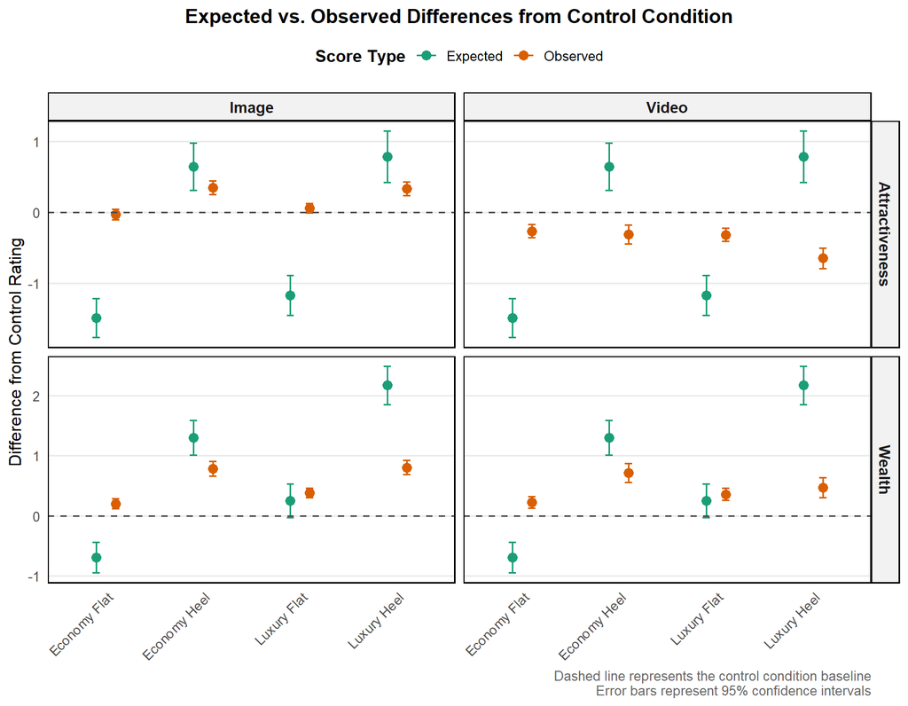

Figure B7.1. Expected (isolated item photograph) versus Observed (worn item) differences from the control condition, by footwear condition, rating dimension, and stimulus type. Error bars represent 95% confidence intervals.

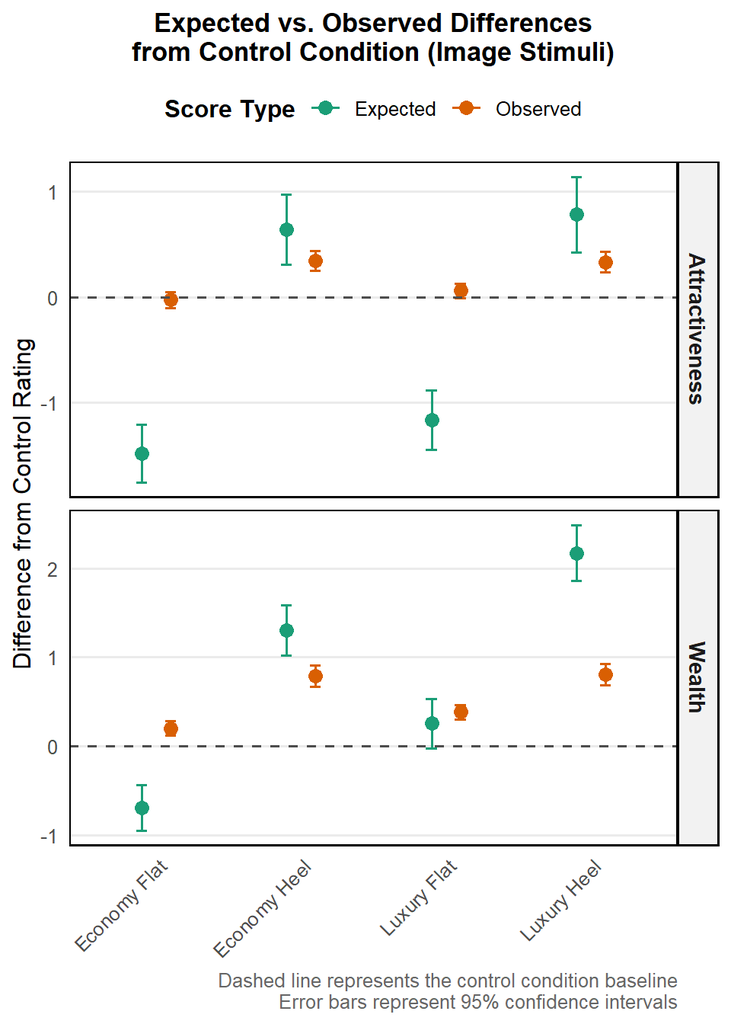

Figure B7.2. Expected versus Observed differences from the control condition, Image stimuli only. Error bars represent 95% confidence intervals.

## **PART VIII: Supplement B8: Walking Proficiency in the Video Stimuli**

Walking proficiency was rated by three researchers, who were not blind to the study hypotheses, for each video stimulus (54 models × 5 footwear conditions = 270 videos) on a scale from 1 to 10. Ratings were collected via formr. This section assesses inter-rater reliability, aggregates the ratings to one proficiency score per video, and tests whether walking proficiency accounts for the attractiveness and wealth ratings of the video stimuli in the 2×2 factorial models (Supplement B4).

### 32. Data Import and Preparation of Proficiency Ratings

### 33. Inter-Rater Reliability

```
## Call: psych::ICC(x = prof_ratings[, c("R1", "R2", "R3")])
##
## Intraclass correlation coefficients
##                          type  ICC   F df1 df2       p lower bound upper bound
## Single_raters_absolute   ICC1 0.46 3.6 269 540 3.1e-36        0.39        0.53
## Single_random_raters     ICC2 0.51 8.6 269 538 4.9e-98        0.14        0.72
## Single_fixed_raters      ICC3 0.72 8.6 269 538 4.9e-98        0.67        0.76
## Average_raters_absolute ICC1k 0.72 3.6 269 540 3.1e-36        0.66        0.77
## Average_random_raters   ICC2k 0.76 8.6 269 538 4.9e-98        0.33        0.89
## Average_fixed_raters    ICC3k 0.88 8.6 269 538 4.9e-98        0.86        0.91
##
##  Number of subjects = 270     Number of Judges =  3
## See the help file for a discussion of the other 4 McGraw and Wong estimates,
```

```
##          R1       R2       R3
## M  6.655556 5.114815 7.770370
## SD 2.633052 1.713104 1.839026
```

### 34. Aggregated Proficiency Scores per Video

```
##      Condition proficiency.M proficiency.SD proficiency.n
## 1      Control     7.9444444      0.9105715    54.0000000
## 2 Economy Flat     7.6975309      0.9610191    54.0000000
## 3 Economy Heel     5.0370370      1.3577430    54.0000000
## 4  Luxury Flat     7.6172840      0.9547573    54.0000000
## 5  Luxury Heel     4.2716049      1.2590537    54.0000000
```

### 35. Merging Proficiency Scores with the 2×2 Factorial Data

### 36. Attractiveness Models with Walking Proficiency (Video Stimuli)

```
## Linear mixed model fit by REML. t-tests use Satterthwaite's method [
## lmerModLmerTest]
## Formula:
## Rating ~ Trait_Exaggeration * Cost + proficiency_c + (1 | block/Model) +
##     (1 | code)
##    Data: body_df_attract_factorial_video_prof
##
## REML criterion at convergence: 19229.8
##
## Scaled residuals:
##     Min      1Q  Median      3Q     Max
## -3.6012 -0.6447 -0.0355  0.5974  3.8470
##
## Random effects:
##  Groups      Name        Variance Std.Dev.
##  code        (Intercept) 1.7311   1.3157
##  Model:block (Intercept) 0.4184   0.6468
##  block       (Intercept) 0.0000   0.0000
##  Residual                1.6481   1.2838
## Number of obs: 5454, groups:  code, 279; Model:block, 54; block, 11
##
## Fixed effects:
##                             Estimate Std. Error         df t value Pr(>|t|)
## (Intercept)                  4.72405    0.11953  128.90523  39.520   <2e-16 ***
## Trait_Exaggeration1         -0.44736    0.04712 3442.06541  -9.495   <2e-16 ***
## Cost1                        0.02158    0.01842 5181.61106   1.172    0.241
## proficiency_c                0.35927    0.02921 3040.05360  12.300   <2e-16 ***
## Trait_Exaggeration1:Cost1   -0.01122    0.01805 5175.01305  -0.622    0.534
## ---
## Signif. codes:  0 '***' 0.001 '**' 0.01 '*' 0.05 '.' 0.1 ' ' 1
##
## Correlation of Fixed Effects:
##             (Intr) Trt_E1 Cost1  prfcn_
## Trt_Exggrt1 -0.001
## Cost1        0.000  0.306
## proficncy_c  0.001 -0.929 -0.330
## Trt_Exg1:C1  0.000 -0.251 -0.090  0.269
## optimizer (nloptwrap) convergence code: 0 (OK)
## boundary (singular) fit: see help('isSingular')
```

```
## Type III Analysis of Variance Table with Satterthwaite's method
##                          Sum Sq Mean Sq NumDF  DenDF  F value Pr(>F)
## Trait_Exaggeration      148.575 148.575     1 3442.1  90.1470 <2e-16 ***
## Cost                      2.263   2.263     1 5181.6   1.3733 0.2413
## proficiency_c           249.354 249.354     1 3040.1 151.2939 <2e-16 ***
## Trait_Exaggeration:Cost   0.637   0.637     1 5175.0   0.3863 0.5343
## ---
## Signif. codes:  0 '***' 0.001 '**' 0.01 '*' 0.05 '.' 0.1 ' ' 1
```

```
## Data: body_df_attract_factorial_video_prof
## Models:
## model_attract_video_base: Rating ~ Trait_Exaggeration * Cost + (1 | block/Model) + (1 | code)
## model_attract_video_prof: Rating ~ Trait_Exaggeration * Cost + proficiency_c + (1 | block/Model) + (1 | code)
##                          npar   AIC   BIC  logLik -2*log(L)  Chisq Df
## model_attract_video_base    8 19360 19412 -9671.8     19344
## model_attract_video_prof    9 19221 19281 -9601.7     19203 140.21  1
##                          Pr(>Chisq)
## model_attract_video_base
## model_attract_video_prof  < 2.2e-16 ***
## ---
## Signif. codes:  0 '***' 0.001 '**' 0.01 '*' 0.05 '.' 0.1 ' ' 1
```

```
##                              Baseline Proficiency
## (Intercept)                4.72321928  4.72404611
## Trait_Exaggeration1        0.09129424 -0.44735675
## Cost1                      0.09629447  0.02158045
## Trait_Exaggeration1:Cost1 -0.07103090 -0.01122014
```

```
## Cost = Economy:
##  Trait_Exaggeration emmean    SE  df asymp.LCL asymp.UCL
##  Flat                 4.84 0.147 Inf      4.55      5.13
##  Heel                 4.80 0.147 Inf      4.51      5.09
##
## Cost = Luxury:
##  Trait_Exaggeration emmean    SE  df asymp.LCL asymp.UCL
##  Flat                 4.79 0.147 Inf      4.50      5.08
##  Heel                 4.46 0.147 Inf      4.18      4.75
##
## Degrees-of-freedom method: asymptotic
## Confidence level used: 0.95
```

```
## Cost = Economy:
##  Trait_Exaggeration emmean    SE  df asymp.LCL asymp.UCL
##  Flat                 4.28 0.131 Inf      4.03      4.54
##  Heel                 5.20 0.128 Inf      4.95      5.45
##
## Cost = Luxury:
##  Trait_Exaggeration emmean    SE  df asymp.LCL asymp.UCL
##  Flat                 4.26 0.130 Inf      4.01      4.52
##  Heel                 5.14 0.135 Inf      4.87      5.40
##
## Degrees-of-freedom method: asymptotic
## Confidence level used: 0.95
```

```
## Cost = Economy:
##  contrast    estimate     SE  df z.ratio p.value
##  Flat - Heel   -0.917 0.0921 Inf  -9.961  <.0001
##
## Cost = Luxury:
##  contrast    estimate     SE  df z.ratio p.value
##  Flat - Heel   -0.872 0.1090 Inf  -8.000  <.0001
##
## Degrees-of-freedom method: asymptotic
```

```
##             R2m       R2c
## [1,] 0.00538388 0.5996845
```

```
##             R2m      R2c
## [1,] 0.04772116 0.586718
```

```
##      Trait_Exaggeration                    Cost           proficiency_c
##                7.344567                1.122051                7.544204
## Trait_Exaggeration:Cost
##                1.078237
```

### 37. Wealth Models with Walking Proficiency (Video Stimuli)

```
## Linear mixed model fit by REML. t-tests use Satterthwaite's method [
## lmerModLmerTest]
## Formula:
## Rating ~ Trait_Exaggeration * Cost + proficiency_c + (1 | block/Model) +
##     (1 | code)
##    Data: body_df_wealth_factorial_video_prof
##
## REML criterion at convergence: 18382.5
##
## Scaled residuals:
##     Min      1Q  Median      3Q     Max
## -4.2649 -0.5980 -0.0265  0.5851  5.0943
##
## Random effects:
##  Groups      Name        Variance  Std.Dev.
##  code        (Intercept) 9.719e-01 9.858e-01
##  Model:block (Intercept) 1.145e-01 3.383e-01
##  block       (Intercept) 8.990e-10 2.998e-05
##  Residual                1.463e+00 1.209e+00
## Number of obs: 5446, groups:  code, 279; Model:block, 54; block, 11
##
## Fixed effects:
##                             Estimate Std. Error         df t value Pr(>|t|)
## (Intercept)                  4.88008    0.07671  191.36093  63.617  < 2e-16 ***
## Trait_Exaggeration1         -0.69489    0.04148 1141.89052 -16.752  < 2e-16 ***
## Cost1                       -0.04981    0.01722 5100.53011  -2.893  0.00384 **
## proficiency_c                0.36236    0.02540  855.65398  14.266  < 2e-16 ***
## Trait_Exaggeration1:Cost1   -0.03360    0.01692 5162.46520  -1.985  0.04715 *
## ---
## Signif. codes:  0 '***' 0.001 '**' 0.01 '*' 0.05 '.' 0.1 ' ' 1
##
## Correlation of Fixed Effects:
##             (Intr) Trt_E1 Cost1  prfcn_
## Trt_Exggrt1 -0.002
## Cost1       -0.001  0.282
## proficncy_c  0.002 -0.919 -0.307
## Trt_Exg1:C1  0.000 -0.229 -0.078  0.249
## optimizer (nloptwrap) convergence code: 0 (OK)
## boundary (singular) fit: see help('isSingular')
```

```
## Type III Analysis of Variance Table with Satterthwaite's method
##                         Sum Sq Mean Sq NumDF  DenDF  F value    Pr(>F)
## Trait_Exaggeration      410.46  410.46     1 1141.9 280.6458 < 2.2e-16 ***
## Cost                     12.24   12.24     1 5100.5   8.3677  0.003836 **
## proficiency_c           297.66  297.66     1  855.7 203.5200 < 2.2e-16 ***
## Trait_Exaggeration:Cost   5.77    5.77     1 5162.5   3.9418  0.047153 *
## ---
## Signif. codes:  0 '***' 0.001 '**' 0.01 '*' 0.05 '.' 0.1 ' ' 1
```

```
## Data: body_df_wealth_factorial_video_prof
## Models:
## model_wealth_video_base: Rating ~ Trait_Exaggeration * Cost + (1 | block/Model) + (1 | code)
## model_wealth_video_prof: Rating ~ Trait_Exaggeration * Cost + proficiency_c + (1 | block/Model) + (1 | code)
##                         npar   AIC   BIC  logLik -2*log(L)  Chisq Df Pr(>Chisq)
## model_wealth_video_base    8 18546 18598 -9264.7     18530
## model_wealth_video_prof    9 18373 18432 -9177.3     18355 174.94  1  < 2.2e-16
##
## model_wealth_video_base
## model_wealth_video_prof ***
## ---
## Signif. codes:  0 '***' 0.001 '**' 0.01 '*' 0.05 '.' 0.1 ' ' 1
```

```
##                              Baseline Proficiency
## (Intercept)                4.87793228  4.88008397
## Trait_Exaggeration1       -0.15130297 -0.69488631
## Cost1                      0.02555426 -0.04981323
## Trait_Exaggeration1:Cost1 -0.09381003 -0.03360168
```

```
## Cost = Economy:
##  Trait_Exaggeration emmean    SE  df asymp.LCL asymp.UCL
##  Flat                 4.66 0.101 Inf      4.46      4.86
##  Heel                 5.15 0.101 Inf      4.95      5.35
##
## Cost = Luxury:
##  Trait_Exaggeration emmean    SE  df asymp.LCL asymp.UCL
##  Flat                 4.79 0.101 Inf      4.60      4.99
##  Heel                 4.91 0.101 Inf      4.71      5.11
##
## Degrees-of-freedom method: asymptotic
## Confidence level used: 0.95
```

```
## Cost = Economy:
##  Trait_Exaggeration emmean     SE  df asymp.LCL asymp.UCL
##  Flat                 4.10 0.0907 Inf      3.92      4.28
##  Heel                 5.56 0.0866 Inf      5.39      5.73
##
## Cost = Luxury:
##  Trait_Exaggeration emmean     SE  df asymp.LCL asymp.UCL
##  Flat                 4.27 0.0898 Inf      4.09      4.44
##  Heel                 5.59 0.0946 Inf      5.40      5.77
##
## Degrees-of-freedom method: asymptotic
## Confidence level used: 0.95
```

```
## Cost = Economy:
##  contrast    estimate     SE  df z.ratio p.value
##  Flat - Heel    -1.46 0.0821 Inf -17.745  <.0001
##
## Cost = Luxury:
##  contrast    estimate     SE  df z.ratio p.value
##  Flat - Heel    -1.32 0.0965 Inf -13.704  <.0001
##
## Degrees-of-freedom method: asymptotic
```

```
##             R2m       R2c
## [1,] 0.01150714 0.4663405
```

```
##             R2m      R2c
## [1,] 0.07369433 0.468482
```

```
##      Trait_Exaggeration                    Cost           proficiency_c
##                6.404689                1.103915                6.575716
## Trait_Exaggeration:Cost
##                1.066305
```

### 38. Control Analysis: Walking Proficiency and Image Attractiveness

```
## Type III Analysis of Variance Table with Satterthwaite's method
##                          Sum Sq Mean Sq NumDF  DenDF F value   Pr(>F)
## Trait_Exaggeration      29.2366 29.2366     1 4663.7 22.0589 2.72e-06 ***
## Cost                     2.7069  2.7069     1 5167.7  2.0424   0.1530
## proficiency_c            1.3035  1.3035     1 4469.9  0.9835   0.3214
## Trait_Exaggeration:Cost  2.5668  2.5668     1 5157.4  1.9366   0.1641
## ---
## Signif. codes:  0 '***' 0.001 '**' 0.01 '*' 0.05 '.' 0.1 ' ' 1
```

### 39. Visualization: Walking Proficiency and Ratings of Video Stimuli

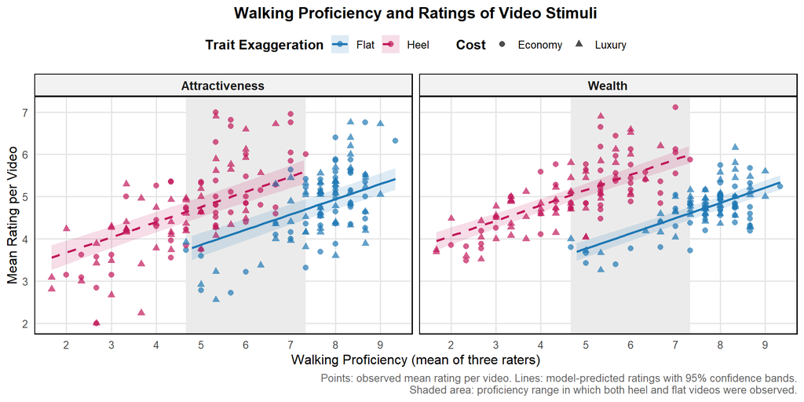

Figure B8.1. Walking proficiency and mean attractiveness and wealth ratings of video stimuli. Points show observed mean ratings per video; lines show ratings predicted by the proficiency-adjusted 2×2 models (averaged over cost) with 95% confidence bands. The shaded area marks the proficiency range in which both heel and flat videos were observed.